# La composición social de las escuelas y su relación con el rendimiento en lenguaje y matemática de los estudiantes secundarios chilenos

Carlos Budnevich Portales (tesista)

Juan Carlos Castillo (Profesor Guía)

**Resumen**

La masiva intromisión de agentes privados en la educación a partir de las reformas de 1980 derivó en la configuración de un mercado escolar, teniendo dos grandes consecuencias: Primero, se exacerban las diferencias de rendimiento según nivel socioeconómico; En segundo lugar, en virtud de los mecanismos económicos, sociales y culturales altamente selectivos y discriminatorios utilizados por los establecimientos, se produce un sistema educacional altamente segregado. Los individuos de origen socioeconómico más bajo, los grupos étnicos, y los migrantes, tienden a concentrarse en escuelas públicas, mientras los estudiantes de élite se concentran en colegios particulares pagados, habiendo una alta segmentación cultural, social y económica de la matrícula de los establecimientos. La literatura internacional muestra, por un lado, el efecto negativo que tiene el nivel socioeconómico promedio bajo de las aulas, una alta proporción étnica, y una alta proporción de migrantes, en el rendimiento académico de los alumnos más desaventajados. Por otro lado, la composición de género de las aulas también sería fundamental pues las mujeres obtendrían peores resultados en matemática en aulas mixtas en comparación a los resultados obtenidos cuando están en aulas sólo con mujeres. Pese a lo anterior, habría mecanismos mitigadores de los malos resultados académicos exhibidos por estos individuos. De este modo, mayores niveles de heterogeneidad socioeconómica y cultural podrían favorecer el rendimiento de los estudiantes más pobres, y minorías étnicas/migrantes. La presente investigación tiene como propósito central evaluar la relación que tiene el grado de heterogeneidad de la composición escolar en términos socioeconómicos, étnicos/nacionalidad, y de género con el rendimiento académico de las mujeres, indígenas, individuos de bajo nivel socioeconómico y migrantes de II medio en las pruebas SIMCE 2017 de matemática y lenguaje. Para ello, se estimarán modelos multinivel a partir de los datos que proporciona el Ministerio de Educación de la prueba SIMCE.

Palabras clave: **desigualdad**, **educación de mercado**, **segregación educativa**, **composición escolar**, **rendimiento académico**.

# Introducción

La educación es una de las áreas que mayor atención política y social recibe debido a la importancia que reviste en términos del impacto que tiene sobre la fisonomía de las sociedades. Las posibilidades de ascenso social (Palet et al., 2017), la reproducción social de la estructura de clases (Bourdieu et al., 1998; Bourdieu & Passeron, 2009; Hansen, 1997), y la generación de segmentos socialmente separados o sociedades segregadas (Bellei, 2013; Ortiz, 2015; Valenzuela et al., 2014) asociadas a la forma del sistema educativo son sólo algunos elementos de esta área que han sido fruto de extensos debates tanto a nivel internacional como nacional.

Uno de los principales elementos que ha capturado la atención del fenómeno educativo es de qué forma poder mejorar la calidad del proceso educacional, particularmente en lo que refiere a la transmisión y adquisición de habilidades de los alumnos. En ese sentido, en términos de políticas educacionales, la discusión que subyace a esta investigación es de una importancia fundamental.

Se ha sostenido, sistemáticamente, que los resultados académicos o la efectividad escolar dependen, exclusivamente, de variables asociadas a la gestión pedagógica, la calidad docente, y los recursos materiales que disponen los establecimientos educacionales. Contraria a esa visión, hay quienes (Mizala & Torche, 2012; Ortiz, 2015; Taut & Escobar, 2012; Thrupp et al., 2002) plantean la importancia que tiene la composición social de los establecimientos educativos en lo que respecta al rendimiento de los estudiantes y su efecto perjudicial sobre aquellos más desaventajados. Las consecuencias que se derivan de cada una de estas posturas divergen sustancialmente, pues mientras la primera posición nos sugiere que la política educativa debe centrarse en la inyección de recursos económicos y capital para mejorar la calidad educacional, la segunda da cuenta de la relevancia que asume la fisonomía y estructura del sistema educativo, enfatizando en la importancia que tiene la igualdad y equidad (Mizala & Torche, 2012). En efecto, si se logra demostrar que una mayor mixtura o heterogeneidad social tiene un impacto positivo en el rendimiento de los estudiantes históricamente marginados las orientaciones de la política educacional deben ir en la dirección de reformar la estructura del sistema procurando promover una mayor integración social a todo nivel en términos de generar escuelas más heterogéneas.

Chile resulta ser un interesante caso de estudio en esta materia, en virtud de la novedad comprendida en las reformas que se han implementado en las últimas décadas. Dos de ellas merecen especial atención debido al elevado impacto que han tenido. Primeramente, el paquete de reformas que fue implementado a partir de 1980 por la dictadura civil militar. Estas medidas producen una serie de cambios sustanciales en el funcionamiento y estructura administrativa del sistema escolar. Uno de los más importantes, refiere al nuevo rol que asume el mercado, el cual irrumpe como un proveedor central en la educación secundaria despojando al Estado en cuanto al rol protagónico que había desempeñado. De este modo, proliferan los establecimientos privados que, pese a recibir financiamiento estatal, emplean mecanismos fuertemente segregadores (OECD, 2016). Pruebas de admisión arbitraria, selección de los estudiantes según criterios discrecionales (entrevistas familiares, revisión de imágenes de los postulantes, estado civil de los padres, entre otros), segmentación socioeconómica de la matrícula derivado de las mensualidades cobradas, en definitiva, se consolida un esquema educacional edificado a partir de la discriminación social hacia los estudiantes (Bellei, 2007, 2013; Belleï, 2015; Contreras et al., 2010; Garcia-Huidobro, 2007; Treviño et al., 2014; Valenzuela et al., 2008).

Basado en el paradigma de mercado, se procuró hacer competir a las escuelas por la captación de los estudiantes a partir del denominado “voucher”, que es una subvención otorgada por el Estado sin distinción (esto es, independiente de si lucra o no y de su dependencia administrativa) por la cantidad de alumnos matriculados en cada escuela y la asistencia efectiva que ellos mostraran. Esto obligaría a los establecimientos a impulsar políticas que mejoraran los logros educacionales para poder captar más alumnos y así poder financiarse y subsistir.

Luego, el segundo gran punto de inflexión de la educación chilena de las últimas décadas, se remite a la recién (2015) aprobada nueva ley de educación pública. Los contenidos de la reforma contemplaron trascendentales cambios que significaron una radical reorientación de los antiguos cimientos y directrices que habían marcado la pauta de la educación chilena desde el conjunto de reformas ejecutadas en 1980. El traspaso de la administración de la educación desde los municipios al aparato estatal (mediados por los servicios locales de educación), la erradicación de mecanismos selectivos en colegios que reciban algún tipo de financiamiento público, y el fin al copago revierten, parcialmente, la tendencia mercantil y discriminatoria que se había impregnado en el corazón del sistema educacional. Para cumplir con los objetivos anteriores, se diseña un nuevo mecanismo de admisión escolar (sistema de admisión escolar, en adelante “SAE”), que busca compatibilizar las preferencias de los padres con criterios de justicia en la asignación de la oferta educativa (pública).

Contrario al objetivo declarado por los promotores de la gran reforma educacional de 1980 de mejorar la competitividad en el sistema educacional para incentivar una mejora sistemática en los logros educacionales, lo que se ha producido es una alta estratificación social del rendimiento académico (Informe MINEDUC, 2018). La diferencia de puntaje en matemática entre el quintil más rico y el más pobre en estudiantes de II medio es de 102 puntos para el año 2018, cuando 10 años atrás era de 115, lo cual revela los pocos avances en materia de reducir la brecha de aprendizaje entre individuos de distinto origen socioeconómico. En consecuencia, hay luces sobre una estrecha relación entre el nivel socioeconómico del estudiante y el rendimiento académico.

Asimismo, como consecuencia del sistema educacional altamente privatizado y selectivo, los resultados académicos que tiene cada estudiante estarían fuertemente vinculado al tipo de establecimiento al que cada uno accede en virtud de motivos socioeconómicos, de género, y culturales. Entonces, el sistema educacional no sólo ha sido ostensiblemente ineficiente, sino que también ha producido altos grados de segregación social entre las escuelas y alta homogeneidad interna (Ortiz, 2015; Villalobos et al., 2020). Incluso, según la prueba PISA, Chile tiene un sistema educativo con los establecimientos educacionales que tienen una menor diversidad socioeconómica, entre los países que pertenecen a la OCDE y los que no pertenecen cuyos datos son comparables (OECD, 2016; Vazquez, 2016).

De esta forma, cada estudiante estaría condicionado por las características agregadas que tiene la escuela a la que asiste. Mientras los individuos que son de niveles socioeconómicos más altos tendrían compañeros con características similares, aquellos de niveles socioeconómicos más bajos les ocurriría algo similar (Villalobos et al., 2020). Lo mismo ocurriría para grupos sociales subalternos como los indígenas y los migrantes, generando entornos de aprendizaje en el aula vulnerables y condiciones poco propicias para un buen aprendizaje. Aquellos grupos privilegiados tendrían a su favor compañeros también privilegiados promoviendo el aprendizaje y, en la contracara, los grupos subalternos que se rodean de individuos con dificultades de modo que podrían ver empeorado su rendimiento (Bellei, 2013). Es lo que se conoce en la literatura como “efecto par” o efecto de los compañeros.

En esta investigación procuraremos dilucidar el efecto que tienen los compañeros en el rendimiento individual, específicamente, el impacto de la diversidad de género, cultural, y socioeconómica de estos. Ha sido extensamente documentada la potencia explicativa que tiene el nivel socioeconómico promedio de los establecimientos, siendo una de las variables que mayor atención ha suscitado en los investigadores en educación (Bellei, 2013; Canales & Webb, 2018; Mizala & Torche, 2012; Valenzuela et al., 2014). Sin embargo, el estudio acerca de la diversidad social/cultural/género de aula ha tenido un menor desarrollo académico y resultados algo contradictorios. En lo que respecta al género, no hay consenso acerca de la composición de género más adecuada para un buen rendimiento en matemática de las mujeres. Hay investigaciones que señalan que las mujeres obtienen mucho mejor rendimiento en aulas sin hombres (Paredes, 2018), mientras otras han descartado diferencias de aprendizaje entre escuelas mixtas/no mixtas (Villalobos et al., 2016).

Sobre la diversidad socioeconómica, si bien se ha mostrado claramente que escuelas más heterogéneas en términos socioeconómicos producen un efecto lineal y positivo en el rendimiento académico (Mizala & Torche, 2012; Ortiz, 2015; Taut & Escobar, 2012) y también que la heterogeneidad favorece más a estudiantes de menores ingresos, hay ciertos elementos de esta relación sobre los cuales aún no hay claridad. En primer lugar, la forma que asume la relación entre ambas variables y, en segundo lugar, no es claro qué niveles o grados de heterogeneidad son deseables en términos de favorecer el aprendizaje de estudiantes de bajo nivel socioeconómico.

En cuanto a la diversidad cultural (considerando la etnia y nacionalidad de los estudiantes), la evidencia para nuestro país muestra que para las minorías étnicas es perjudicial altos niveles de concentración de población indígena en un mismo establecimiento escolar para efectos del rendimiento académico (Canales & Webb, 2018). No obstante, al igual que en el caso de la heterogeneidad socioeconómica no se sabe en qué punto crítico se vuelve negativa la concentración étnica, de modo que no sabemos qué niveles de heterogeneidad cultural son deseables para el rendimiento académico de minorías étnicas y migrantes.

En suma, la pregunta que se busca responder mediante esta investigación es: ¿En qué medida la heterogeneidad de la composición escolar, en términos socioeconómicos, de género, étnicos, y nacionalidad, se relaciona con los resultados obtenidos por mujeres, indígenas, migrantes, e individuos de bajo nivel socioeconómico en la prueba SIMCE 2017 de matemática y lenguaje?

El texto se divide en cinco secciones: En primer lugar, caracterizamos las desigualdades educativas en Chile, partiendo con una breve revisión histórica de la privatización del sistema educacional, después caracterizamos la desigualdad social en el rendimiento académico, y luego una definición de calidad educativa. En segundo lugar, indagamos en la segregación de la educación chilena y su vínculo con la composición social de los establecimientos. Tercero, se revisó literatura relevante en relación con el efecto que tienen los compañeros en el aprendizaje de los alumnos. Cuarto, se enuncian los objetivos e hipótesis de investigación de acuerdo con la revisión de literatura y la pregunta que orienta la investigación. Por último, se describe la metodología a utilizar.

# Desigualdades educativas

## Privatización del sistema educacional chileno

Los antecedentes de la formalización de un sistema educacional se remontan a inicios del Siglo XIX. En aquellos tiempos, el acceso a la educación formal estaba resguardado, exclusivamente, para los miembros de la élite nacional. La provisión de la educación escolar descansaba casi completamente en congregaciones religiosas e instructores privados, de modo que no existía el desarrollo de una institucionalidad educativa más allá de iniciativas privadas y gremiales (Bellei et al., 2018).

Recién a mediados de siglo, comienzan a proliferar liceos fiscales con la consiguiente expansión de la educación pública. En consecuencia, el aparato estatal emerge, gradualmente, como un nuevo actor en el escenario educativo, siempre conviviendo con las iniciativas privadas ya mencionadas. Con el paso del tiempo, desde la década de los 50’ en adelante, la educación pública se torna cada vez más mayoritaria, no obstante, enfocada en las capas medias y altas de la sociedad chilena (Bellei & Pérez, 2010; Nuñez Prieto, 2015). De esta forma, el Estado acrecienta su influencia en materia educacional, ampliando la cobertura y participación que este tiene en el sistema escolar, pero aun relegando a ciertas fracciones sociales de la población (Bellei et al., 2018).

La figura de un Estado promotor de la educación se consolida y acentúa con las reformas introducidas por el gobierno de Frei Montalva. En efecto, Núñez (1984) señala que estas reformas terminan por fraguar un Estado fuertemente centralista y burocrático, proceso que ya se había iniciado décadas atrás con la creación del ministerio de educación el año 1927. De esta manera, el aparato estatal se vuelve crucial en el sistema educativo nacional, concentrando funciones normativas, curriculares, supervisoras, administrativas, y financieras.

El proceso de consolidación de un Estado Docente y de ampliación masiva del acceso a la educación secundaria se vio interrumpido y radicalmente modificado producto del golpe civil militar perpetrado el año 1973. Desde entonces, se instaura un nuevo régimen político con rasgos autoritarios. En este contexto, la dictadura civil militar impulsó grandes transformaciones en el campo educacional: En primer lugar, generó las condiciones para un abandono del Estado como principal agente de la educación deteriorando significativamente la educación pública; y, en segundo lugar, sustituye al histórico Estado activo o “Docente” por la introducción de mecanismos de mercado y la vigorosa entrada del mundo privado en la provisión de la educación (Bafalluy, 1983; Belleï, 2015; Jofre, 1988).

A grandes rasgos, enmarcado en el proceso de socavar la estructura estatal en su misión educacional, se impulsa la gran reforma de municipalización de la educación el año 1980. Esta, introdujo tres cambios fundamentales: En primer término, reestructuró completamente el sistema de financiamiento y, en segunda instancia, redujo considerablemente el rol y las atribuciones del Estado. Desde ahí en más, los establecimientos educacionales reciben financiamiento mediante los denominados “vouchers” que son montos de plata que otorga el Estado a cada establecimiento según la asistencia efectiva de sus alumnos a sus establecimientos. Dicho monto se da independiente si el establecimiento posee o no fines de lucro (Bellei et al., 2018). El propósito de este esquema descansaba en la idea de que las escuelas, al conseguir financiamiento exclusivamente mediante estos vouchers, iban a tener que competir por los alumnos de modo que, supuestamente, ello haría que las escuelas mejoraran su servicio educativo en virtud de la necesidad de captar la mayor cantidad de estudiantes posible.

A su vez, el Estado pasa a ser un mero ente que provee de recursos al sector privado, constriñendo sus funciones a sólo garantizar las condiciones para el buen funcionamiento y operación del mercado educacional (Bellei et al., 2018). De este modo, el Ministerio de Educación, que antiguamente era determinante en términos del funcionamiento del sistema escolar, ahora sólo se ocupa de fiscalizar, normar, y supervisar el “mercado educacional”. En este marco, los establecimientos educacionales que administraba el Estado pasan a ser parte de los municipios, en función de la zona geográfica de cada uno.

En este contexto, en la educación privada (incluyendo a los colegios que reciben subvención estatal), comienzan a operar mecanismos de selección altamente arbitrarios, estableciendo procesos de admisión en los cuales se realizaban ciertas exigencias a las familias, al mismo tiempo que filtraban a los estudiantes según el rendimiento académico exhibido en pruebas aplicadas por los establecimientos (Bellei et al., 2018).

Posterior a la reforma de 1980, las políticas educacionales de los gobiernos democráticos tuvieron una continuidad en lo que respecta a los ejes principales del sistema educacional. Se promulgaron algunas iniciativas cuyo propósito era corregir algunas deficiencias: Primero, la subvención escolar preferencial, otorgando a los colegios que recibían alumnos más vulnerables una mayor subvención que el promedio, de forma que las escuelas procuraran captar a los estudiantes más pobres de la población. Segundo, se mejoran las condiciones materiales de las instituciones educativas, invirtiendo cuantiosas sumas en infraestructura, libros, laboratorios, bibliotecas, y aumentando la jornada escolar. Tercero, se implementa una reforma al currículo escolar en la educación parvularia, básica, y media. No obstante, el grueso del sistema educativo escolar chileno mantuvo sus pilares fundamentales intactos.

No es sino hasta el año 2015, en el que se debate arduamente una de las reformas de mayor contenido estructural desde la gran reforma de municipalización de la educación de 1980: La controversial ley de “Nueva educación pública”.

Los principios rectores de esta gran reforma, encuentra su base teórica en los conceptos de inclusión social y encuentro entre estudiantes de distintas culturas, etnias, niveles socioeconómicos, género, nacionalidad o religión. En concordancia con ello, busca erradicar cualquier tipo de mecanismo de admisión arbitraria en establecimientos que reciban financiamiento estatal, conforme a la constitución y los tratados internacionales de derechos humanos (Belleï, 2015).

La dimensión logística de la reforma contiene un alto grado de complejidad por la profundidad estructural que posee este proyecto, con varias transformaciones sustantivas del funcionamiento de la educación pública. Los jardines y liceos públicos dejan de ser administrados por los municipios, traspasando su administración a los 70 Servicios locales de Educación Pública encargados de administrar completamente todos los establecimientos públicos a lo largo del territorio nacional. Como complemento a los servicios locales de educación, se crea una orgánica central denominada “Dirección de Educación Pública” cuyo objetivo central es formular las directrices generales del nuevo sistema a nivel nacional (Bellei et al., 2018).

Con el programa de reformas al sistema educativo chileno, se plantea (Bellei et al., 2018) que la fisonomía de la educación deja de ser “puramente” mercantil, pasando a ser una especie de sistema mixto, en el cual el mercado tiene cierto margen de operación (principalmente, mediante los colegios particulares pagados) y, simultáneamente, un sistema de educación pública robusto con un fuerte apoyo estatal en términos de financiamiento y regulación.

Enmarcado en el mismo proceso de búsqueda de una educación más equitativa y proveedora de igualdad de oportunidades para todos, se implementa un nuevo sistema de admisión escolar (en adelante, SAE). En ese sentido, se proscribe la selección de estudiantes en colegios que reciban financiamiento estatal y, a su vez, se prohibe la posibilidad del cobro de aranceles (copago) por parte de los establecimientos educativos. Para resguardar lo anterior, se diseña un sistema de admisión en el cual un algoritmo dirime el colegio de los estudiantes en función de las preferencias de los padres, igualando la probabilidad de ser seleccionado para todos los alumnos.

En virtud de este nuevo diseño de admisión escolar, era esperable una mayor adhesión al nuevo sistema gracias al énfasis colocado en las preferencias de los padres, al momento de elegir una escuela. Si bien hay una situación de conformidad y percepción de mejoría generalizada debido al cáracter equitativo que caracteriza al sistema, aun existen ciertos reparos.

## Estratificación social del rendimiento académico

La realidad empírica muestra que, pese a los objetivos de quienes impulsaron la gran “modernización” del sistema educacional, el logro académico de los estudiantes no ha exhibido estadísticas particularmente positivas. Tomando los resultados desde una perspectiva temporal de las dos pruebas más importantes que evalúan las habilidades de los estudiantes, sólo en una de ellas hay un aumento sostenido, aunque no de gran magnitud, del puntaje en la prueba SIMCE. En efecto, en la prueba de Matemática, hay una mejora de 14 puntos entre el año 2008 y el año 2018. Mientras en Lenguaje, los resultados académicos son desalentadores, pues hay una disminución en los últimos 10 años de los puntajes obtenidos.

Gráfico 1: Trayectoria del puntaje SIMCE de Matemática II medio.

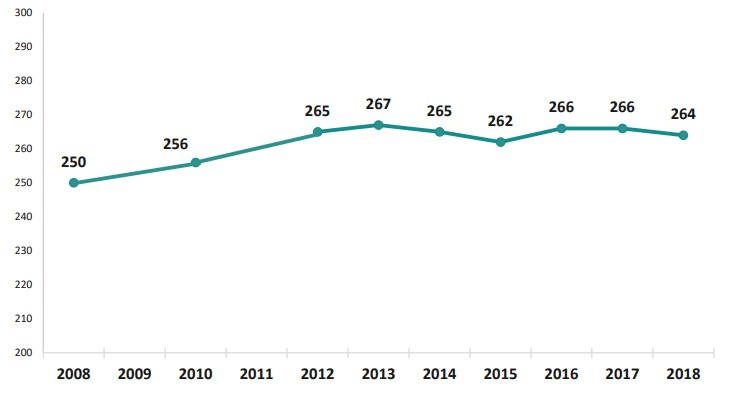

Fuente: Extraído del informe MINEDUC 2018 elaborado por la Agencia de Calidad de la Educación

Gráfico 2: Trayectoria del puntaje SIMCE de Lenguaje II medio.

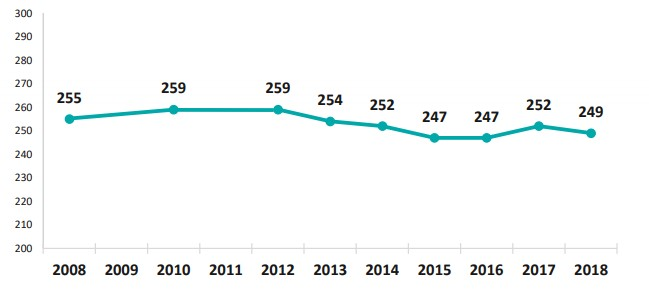

Fuente: Extraído del informe MINEDUC 2018 elaborado por la Agencia de Calidad de la Educación

A su vez, la distribución del rendimiento académico se encuentra fuertemente estratificada en términos sociales. En ese sentido, si evaluamos los resultados a nivel histórico de la prueba SIMCE de matemáticas según nivel socioeconómico podremos advertir que hay diferencias muy pronunciadas entre cada quintil de ingreso. Mientras los alumnos del quintil más rico promedian 330 puntos, aquellos del quintil más pobre tan sólo alcanzan, en promedio, 228 puntos. Esta tendencia ha seguido una trayectoria relativamente estable, pues la brecha que se genera entre cada grupo es parecida tanto para el año 2008 como 2018 (con sólo 13 puntos de diferencia), así como también en los períodos comprendidos entre estos años.

Gráfico 3: Puntaje SIMCE Matemática II medio por quintil de ingreso

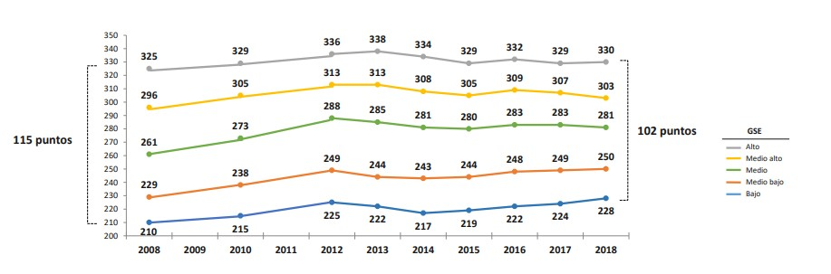

Fuente: Extraído del informe MINEDUC 2018 elaborado por la Agencia de Calidad de la Educación

Gráfico 4: Brechas de género en prueba SIMCE de Lenguaje II medio

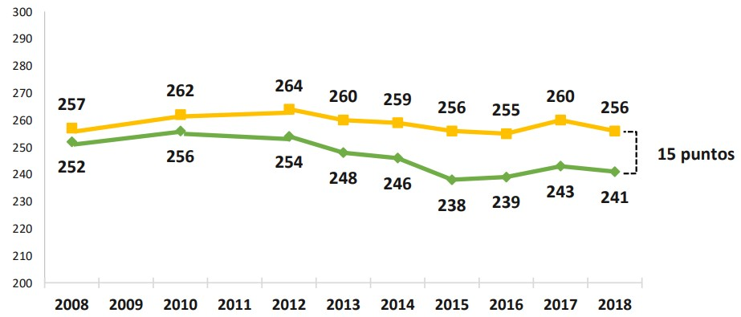

Fuente: Extraído del informe MINEDUC 2018 elaborado por la Agencia de Calidad de la Educación

Gráfico 5: Serie histórica de las brechas de género en prueba PISA de Matemática

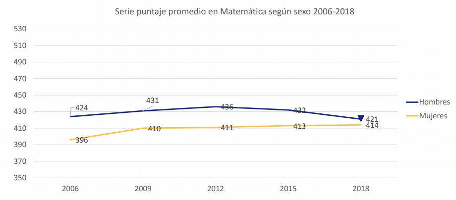

Fuente: Extraído de Informe Agencia de la Calidad de la Educación Pisa 2018

Gráfico 6: Serie histórica de las brechas de género en prueba TIMSS de Matemática

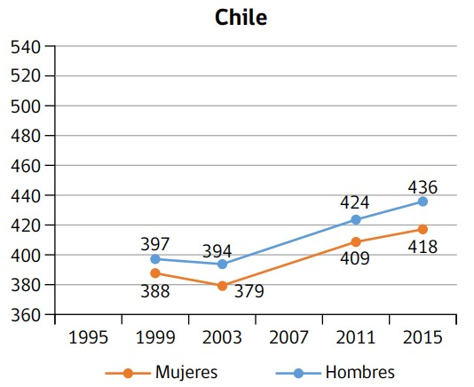

Fuente: Extraído de informe nacional de Agencia de la Calidad de la Educación TIMSS 2015

## Acerca de la calidad educativa en el contexto de un sistema educativo desigual

El rendimiento académico en pruebas estandarizadas es una de las muchas dimensiones que componen una educación de calidad. Teniendo eso a la vista, el concepto de calidad educativa ha sido objeto de numerosos debates tanto en la literatura como en organismos asociados a la supervisión, administración, y regulación de la educación en Chile.

Asociado al modelo de mercado del sistema educacional chileno está la conceptualización de calidad que hacen algunos economistas inspirados en la tradición neoclásica. Si bien no enuncian explícitamente una definición de calidad educativa, es posible identificar una perspectiva de calidad vinculada a algunos elementos centrales que configuran las teorizaciones de dichos autores.

En ese sentido, Becker (1993) sostiene una mirada acerca de la educación estrechamente vinculada al concepto de capital humano. De esta forma, el proceso educativo no sería más que un mecanismo a través del cual se puede aumentar la productividad de los trabajadores con el propósito de impactar positivamente en los indicadores económicos de los países. Es decir, una buena educación sería aquella que produjera individuos más productivos para el sistema económico imperante, omitiendo cualquier otra dimensión humana del proceso educativo.

De este modo, se concibe la educación como “un proceso de aumento de la productividad del individuo y despojándolo de fundamentos en la sociedad que habían sido parte del debate educacional del siglo XX y en especial de aquellos que dicen relación con procesos colectivos y/o supraindividuales (integración social, valores cívicos, etc.). Así, todo proceso educativo, afirma Becker, para ser válido y deseado por la sociedad, debe generar un aumento de capacidades del individuo en el sistema productivo, particularmente, en el mercado laboral, y su agregación y articulación con otros individuos escolarizados llevará a la riqueza de las naciones” (Alejandro Carrasco, 2016, p. 30).

Esta conceptualización va de la mano con el cambio paradigmático implicado en la gran reforma de municipalización de 1980, la cual materializa una visión economicista sobre la educación, fundamentada en las escuelas Austriaca y de Chicago, derivando en una completa subordinación de la discusión educativa a la tecnocracia neoliberal compuesta por economistas formados al alero de dichas escuelas (Alejandro Carrasco, 2016).

Esta noción de calidad educativa experimenta un importante vuelco con la irrupción de las movilizaciones sociales del año 2006 y 2011. Se logra impugnar la perspectiva hegemónica que subordinaba los procesos y la calidad educativa a la orientación mercantil que había asumido la educación chilena. En su lugar, se promueve con fuerza la idea de una educación comprendida desde su potencial integrativo a nivel social, y como una dimensión fundamental de la vida humana que debe ser garantizada por el Estado de Chile (Mayol, 2015).

En la misma dirección, se plantea que la educación debería ser un derecho social consagrado para todos los chilenos sin distinción alguna, cuyo fin sea la promoción activa de la integración social, mediante el reconocimiento al otro diverso (en sus múltiples “formas”) como legítimo, así como también una herramienta igualadora en lo que respecta a su distribución y provisión (Alejandro Carrasco, 2016).

De esta forma, recobra importancia el ideal comunitario que caracterizaba a la educación del siglo XX. Pues el proceso educativo se concibe como un proceso de adquisición de ciudadanía, procurando incentivar la noción de que los individuos forman parte de una misma comunidad política y, por ende, que deben reconocerse como tal. Esta visión contrasta totalmente con aquella mercantil que sólo releva el retorno económico que puede tener la educación (Atria, 2012).

Uno de los principales organismos que ha participado en el debate acerca del concepto de calidad de la educación es la Agencia de Calidad de la Educación. Este es un organismo que fue creado el año 2011 con el propósito de orientar y supervisar el sistema educacional chileno en lo relativo a la equidad y calidad de la educación de nuestro país.

Recogiendo los amplios debates de la literatura y las heterogéneas visiones brindadas por los diferentes actores sociales del mundo educacional, la agencia ha velado por una complejización del constructo de calidad de la educación. Alineado con ese propósito, la agencia señala que: “Se entiende por una educación de calidad un proceso formativo integral que pone en el centro al ser humano en su totalidad, promoviendo un desarrollo consistente e integrado del conjunto de dimensiones, incluyendo la espiritual, la ético-moral, la cognitiva o intelectual, la afectiva, la artística y la de desarrollo físico, entre otras, y que se orienta a proveer oportunidades de desarrollo e integración social al conjunto de los niños y niñas, jóvenes y adultos de manera equitativa e inclusiva, previniendo la discriminación y la segregación de cualquier tipo, garantizando que todas y todos puedan ser ciudadanos autónomos, responsables, proactivos y críticos” (Plan de Aseguramiento de la Calidad Escolar 2016-2019, pp. 16).

Con ese insumo teórico, las políticas públicas disponen de un referente con el cual pueden orientar la evaluación y fiscalización que hacen del sistema educativo. Cabe destacar que la calidad educativa resulta ser un constructo que trasciende los buenos rendimientos en pruebas estandarizadas en las materias tradicionales. Se trata, entonces, de poner el centro en formar personas integrales que sepan convivir armoniosamente en una sociedad diversa (Agencia Calidad de la Educación, 2017). Si bien en la presente investigación nos centraremos en la calidad del proceso educativo asociado a las habilidades cognitivas (medidas a partir de la prueba SIMCE), no perdemos de vista que es sólo una de las muchas dimensiones que configuran el aprendizaje de los alumnos.

Asimismo, es crucial relevar la trascendencia que tiene la inclusión social en una educación de calidad. De este modo, la preocupación no debe residir meramente en formar individuos con aptitudes afectivas, académicas, y cognitivas, sino que también en promover activamente el respeto hacia el otro y el trato igualitario a los individuos independiente de su origen social, cultural, étnico, y de género. De este modo, las escuelas deben centrar su quehacer en hacer de ellas espacios más inclusivos socialmente, combatiendo así la segregación que impera en nuestro sistema educacional.

# Segregación social del sistema educacional chileno

## Una caracterización cuantitativa de la segregación social

El fenómeno de la segregación social se vincula estrechamente al proceso educativo que vivencian los estudiantes. Un sistema educacional más inclusivo, es decir, menos segregado, es socialmente beneficioso para el conjunto de la sociedad, así como también para los individuos. Cuando los sujetos comparten en la sala de clases con individuos de origen social diverso tiene, entre sus consecuencias positivas, desarrollar una mayor tolerancia hacia sujetos de diversa procedencia social, favorece la eliminación de estereotipos y estigmas, es un estímulo importante a la cohesión social de los países, entre otros beneficios (Valenzuela et al., 2008).

Además de tener efectos positivos concretos en muchos indicadores de calidad, una buena educación para todos los individuos independiente de su origen social es deseable puesto que nos acerca al ideario normativo de la igualdad de oportunidades (van de Werfhorst, 2014), fuertemente asentado en las valoraciones morales que hacen los sujetos de las sociedades occidentales.

Conceptualmente, entenderemos la segregación social como “la desigual distribución que poseen los diversos grupos sociales ya sea entre unidades de organización diferentes, entre zonas geográficas o en una combinación de ambos, tal que dichas diferencias de distribución afectan las probabilidades de interacción entre miembros de los diferentes grupos sociales” (James & Taeuber, 1985, p. 45).

En consecuencia, la segregación social de un sistema educacional determinado repercute directamente en el grado de homogeneidad/heterogeneidad de la composición social de los establecimientos escolares.

Como consecuencia de la privatización del sistema educacional chileno, se producen altos niveles de segregación socioeconómica. Siguiendo los datos obtenidos a partir de la prueba PISA, Chile presenta un nivel de segregación escolar muy elevado comparado con los 57 países que participan de la OCDE (González, 2017). Concretamente, nuestro país y Tailandia son los dos países con mayor segregación socioeconómica del sistema educativo, tomando como referencia al 30% más pobre y al 30% más rico, alcanzando valores sobre 0,5 en el índice de Duncan (que procederemos a explicar a continuación), cuando la mayoría de los países se ubican en torno a 0,3-0,4.

Gráfico 7: Evolución de la segregación socioeconómica en el sistema educacional por nivel de ingreso

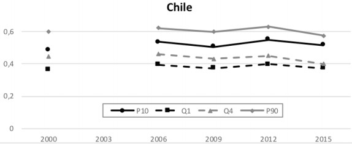

Fuente: Extraído de Murillo et. al (2018): “Evolución de la segregación socioeconómica de las escuelas de América Latina”

Gráfico 8: Índice de inclusión social y académica para países perteneciente a la OCDE

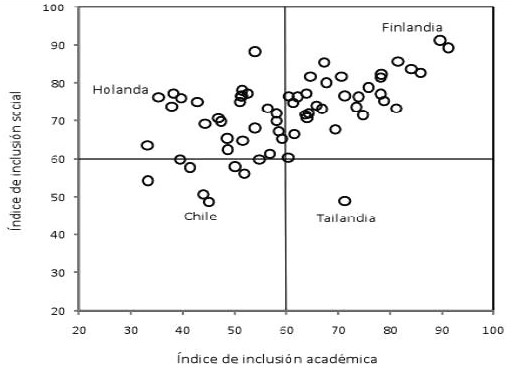

Fuente: Extraído de Bellei (2013): “El estudio de la segregación socioeconómica y académica de la educación chilena. Estudios pedagógicos”

## Relación de la segregación social con la composición de los establecimientos

Siguiendo esta caracterización más general, es posible constatar que el elevado nivel de segregación social del sistema educacional chileno se expresa concretamente en una alta homogeneidad interna de los establecimientos y, también, una alta heterogeneidad entre las escuelas. En ese sentido, Villalobos et al. (2020) señala que el sistema escolar chileno tendría cuatro grupos de escuelas, agrupadas a partir de un conjunto de atributos sociales identificados por el autor (género, etnia, nacionalidad, necesidades educativas especiales, y nivel socioeconómico). Un grupo de establecimientos concentraría a la élite del país, en colegios particular pagados, un segundo grupo que agruparía a estudiantes vulnerables, un tercer grupo que integraría a las clases medias del país, y un cuarto grupo de establecimientos que tendría un elevado grado de heterogeneidad social en términos socioeconómicos y académicos.

Asimismo, la porción de establecimientos heterogéneos se explicaría, fundamentalmente, por razones académicas, de género, y de ingresos. Mientras, la cantidad de colegios heterogéneos en lo que respecta a atributos como etnia, nacionalidad, y necesidades especiales es muy baja. En efecto, es poco probable que los estudiantes de diversas culturas y etnias se encuentren en un mismo establecimiento en la medida que están homogéneamente distribuidos en el sistema educacional. Por el contrario, estudiantes de diferentes géneros, rendimiento e ingreso están más mezclados entre sí, produciendo una mayor mixtura social (Villalobos et al., 2020).

Analizando en detalle los establecimientos educacionales chilenos, podemos observar que un 85,2% es heterogéneo en términos del sexo de los estudiantes, un 12,29% es heterogéneo en términos étnicos, y tan sólo un 5,1% lo es en lo que refiere a la nacionalidad de los estudiantes que componen los establecimientos (Villalobos et al., 2020). Es interesante destacar que son las cifras más actualizadas acerca de la composición escolar de los colegios en Chile.

En consecuencia, el sistema escolar chileno estaría altamente fragmentado en la medida que los diferentes grupos sociales tienen poca interacción entre sí (con algunas excepciones), obstaculizando el desarrollo de una mayor cohesión social y el desarrollo de valores asociados a la aceptación de la diversidad social (Villalobos et al., 2020).

Con un propósito similar, se ha evidenciado (Ortiz, 2015) que el sistema educacional chileno estaría compuesto, a grandes rasgos, por tres tipos de establecimientos. Habría establecimientos compuestos mayoritariamente por estudiantes aventajados (34,4%), establecimientos mixtos o inclusivos socialmente (22,8%), y colegios que concentran predominantemente estudiantes vulnerables o desaventajados (42,8%).

El modo a partir del cual se genera la tipología de establecimientos resulta tener importantes arbitrariedades a ser corregidas. La metodología usada para determinar lo anterior se basa en comparar el nivel socioeconómico promedio de los establecimientos, con la media nacional, realizando una prueba T de dos colas para decidir si cada uno es superior o inferior a dicha media y, conforme a ello, determinar si es de estudiantes aventajados (nivel socioeconómico sobre la media), mixto socialmente (cercano a la media socioeconómica nacional) y compuesto por estudiantes desaventajados (nivel socioeconómico del establecimiento bajo la media).

En términos étnicos, (Treviño et al., 2017) muestra de qué forma se generan los patrones de segregación de la población indígena en Chile. Según este, la segregación de este grupo en particular se explicaría por razones geográficas, esto es, a raíz de la forma en que se asienta la población, donde los sectores indígenas tienden a concentrarse en zonas rurales. De esta forma, habría una diferencia importante respecto a otras formas de segregación social que venían dadas, principalmente, por políticas explícitas de los establecimientos educacionales. Por lo tanto, se concentran de forma importante en las zonas rurales, lugares en los cuales encontraríamos una mayor homogeneidad étnica de los establecimientos, mientras en zonas urbanas dicha homogeneidad interna sería menos acentuada.

## Factores asociados a la segregación social

Respecto a las causas que explican esta elevada magnitud de segregación la evidencia ha demostrado que uno de los principales factores que influiría sería la asimetría de información existente entre los apoderados que eligen las escuelas, mediado por el capital económico y cultural que disponen (Elacqua, 2012). En efecto, las familias de bajos ingresos elegirían los colegios a partir de criterios no educacionales, a saber, según cercanía del hogar fundamentalmente, mientras las familias con mayor capital económico enfocarían su decisión en la calidad académica de las escuelas (Valenzuela et al., 2014). Desde una perspectiva cualitativa (Hernández & Raczynski, 2015), muestran de qué modo la clase media y baja del país producen dinámicas de exclusión social. Los sectores medios fundamentan su elección de escuela según la búsqueda de distinción social, mientras los individuos de familias más pobres se auto excluyen, reforzando la segregación socioeconómica de la matrícula. En virtud de lo anterior, se generarían escuelas con altos niveles de segregación, de manera que las familias pobres quedan relegadas a escuelas de mala calidad y las familias de altos ingresos a las mejores escuelas del país.

La segregación residencial existente en las grandes ciudades del país explicaría una parte importante de la magnitud de la segregación socioeconómica del sistema educacional (Arteaga et al., 2014; Flores, 2006). En efecto, las estimaciones cifran en alrededor de un 8-13% de varianza de la segregación socioeconómica explicada por la segregación residencial, particularmente para el caso de Santiago.

Si bien la estructuración urbana de las ciudades se relaciona con la segregación, ciertos autores (Bonal & Bellei, 2019), mediante entrevistas a apoderados de diversos estratos socioeconómicos, han consignado que los mecanismos de mayor impacto estarían mediados por las dinámicas de mercado del sistema educacional. De este modo, la demanda de los apoderados por educación para sus hijos tendría orientaciones fuertemente influenciadas por la composición social de los establecimientos, buscando espacios con alta homogeneidad interna. En consecuencia, la clase alta busca establecimientos de composición sociocultural elitaria, los sectores medios evitan la educación pública y gratuita para no “mezclarse” con familias de bajos ingresos y, estos últimos, aun cuando una parte importante comparte ese criterio, muchos de ellos decidirán el colegio de sus hijos según cercanía geográfica.

A su vez, la fisionomía del sistema educativo, edificado a partir de mecanismos de selectividad, financiamiento compartido, y escuelas subvencionadas por el Estado respondería a dinámicas de mercado. De esta manera, se incentivaría a los colegios a elegir y seleccionar estudiantes de élite y, en el caso de los colegios con fines de lucro, segmentar también al interior de los colegios de forma tal que los mejores estudiantes estén conformes (Bellei, 2007; Contreras et al., 2010; Elacqua, 2012; Garcia-Huidobro, 2007; Valenzuela et al., 2008).

En la misma dirección, se ha aducido que el factor más relevante que incide en que un colegio agrupe o no a sus estudiantes tiene relación con el nivel de heterogeneidad socioeconómica del establecimiento más que la diversidad académica existente (Treviño et al., 2014). En coherencia con lo anterior, aquellos colegios más heterogéneos socialmente realizan con mayor frecuencia prácticas de agrupamiento que los que tienen una composición social más homogénea.

Por otra parte, Bellei (2013) ha señalado que la segregación socioeconómica de las escuelas chilenas se vincularía positivamente a cuatro factores. Primero, la elevada segregación residencial que exhibe el país. Segundo, la magnitud de la presencia de la educación privada no subvencionada en la comuna. Tercero, la relevancia de los establecimientos particulares subvencionados. Por último, la relevancia del financiamiento compartido en la comuna.

En síntesis, el sistema escolar chileno está dividido en segmentos sociales nítidos, como consecuencia de una serie de políticas educacionales que subyacen al sistema mismo. La combinación de procesos de admisión selectivos, la elección de los padres, el copago, y la segregación residencial serían elementos explicativos de la segregación escolar. En virtud de estos mecanismos, los colegios públicos tenderían a concentrar a la población socialmente más desaventajada, mientras la clase media-baja y clase media asistiría a escuelas particulares subvencionadas (Garcia-Huidobro, 2007).

# Efecto(s) de la composición escolar en el rendimiento académico

Habría dos mecanismos centrales mediante los cuales operaría la segregación social para producir efectos en los logros educacionales (Bellei, 2013): por un lado, a partir de la noción de capital social y, por otro lado, la teoría del efecto de los compañeros, objeto de interés en la presente investigación. De este modo, las inequidades en los resultados educacionales podrían estar asociadas a las consecuencias derivadas de la composición de los establecimientos, lugar en el cual los integrantes podrían tener un impacto beneficioso o negativo en los compañeros con los que comparten el aula escolar.

El modo en que operaría el impacto positivo de una mayor diversidad étnica, social, económica y de género en el rendimiento académico serían los siguientes (Dronkers & van der Velden, 2013): (1) en escuelas más diversas aquellos estudiantes de un origen privilegiado tenderían a colaborar con aquellos que tienen mayores problemáticas o bien siendo una especie de ejemplo para estos últimos; (2) los estudiantes tendrían mayores posibilidades de enfrentarse a un curriculum desafiante y que promueva activamente habilidades de todo tipo, pues los profesores suelen transmitir dichas enseñanzas en contextos en los cuales están los mejores estudiantes o de origen privilegiado; (3) los estudiantes más capaces aprenderían más debido al proceso de enseñanza que ellos practican con los compañeros que requieren que les expliquen las diferentes materias.

No obstante, también es posible que la diversidad del aula tenga efectos inhibitorios de un buen rendimiento académico, siendo preferible una mayor homogeneidad interna. Tres mecanismos se han descrito respecto a este (Dronkers & van der Velden, 2013): (1) un cuerpo estudiantil más homogéneo incrementa las posibilidades de especialización de los profesores gracias a esa homogeneidad, propendiendo a una mayor efectividad de la escuela; (2) En aulas más homogéneas menos tiempo requiere ser gastado en generar puentes entre los estudiantes de diverso origen cultural y social, permitiendo destinar ese tiempo a mejorar la enseñanza y el aprendizaje de los estudiantes; (3) La confianza entre profesores, apoderados, y estudiantes, en contextos de un cuerpo estudiantil más homogéneo, es considerablemente mayor propiciando un mayor involucramiento de cada actor y, por ende, aumentando la efectividad de las escuelas en términos del aprendizaje resultante de los alumnos.

## Efecto de composición socioeconómica

Antes de indagar en la literatura sobre el tema, es necesario distinguir dos conceptos que con frecuencia aparecen en la literatura acerca de composición escolar o efecto par de los compañeros. Por un lado, está el concepto de composición y, por otro, el de heterogeneidad. Mientras el primero hace referencia a un promedio o proporción de un atributo determinado (por ejemplo, el nivel socioeconómico promedio de un aula), el segundo alude a la dispersión de alguna característica social definida (Dronkers & van der Velden, 2013).

La primera aproximación empírica al fenómeno de la composición escolar referida al nivel socioeconómico data de varias décadas (Coleman, 1965), quien logró distinguir, por un lado, la importante influencia que tienen ciertas características individuales (en inglés, el background), principalmente, el origen socioeconómico de los individuos de, por otro, el efecto que tiene la agregación de esta (y otras) características individuales en el contexto de un establecimiento o sala de clases. De ahí el término de efecto de composición, estrechamente ligado al nivel socioeconómico promedio de una sala de clases o establecimiento escolar, según ciertas variables tradicionales (libros en el hogar, ingreso de los padres, grado educacional alcanzado por progenitores, etc.).

La discusión acerca de la naturaleza del efecto de composición o mixtura social reviste de interés mundial. Han sido muchos los países en los cuales se ha indagado el tópico de composición escolar y rendimiento académico. Por cierto, es un asunto aún no resuelto, pero sí con algunos consensos mínimos. Thrupp et al. (2002) sostienen que después de décadas de investigación acerca de los efectos de composición o mixtura social de las escuelas, el consenso acerca de la naturaleza y tamaño de estos efectos es notablemente poco, una conclusión también evidenciada por muchos otros autores (Angrist & Lang, 2004; Hoxby, 2000; Hoxby & Weingarth, 2005).

En Nueva Zelanda, país donde hay un sistema educacional con un nivel de estratificación y segregación social relativamente bajo, la varianza del puntaje entre escuelas es bastante baja. Sólo un 5-9% de la varianza del rendimiento de los estudiantes está contenida entre las escuelas. Sobre ella, tanto la composición cultural (es decir, proporción de individuos de origen maorí, asiático, y de islas pacificas) como la composición socioeconómica medida a partir del nivel socioeconómico promedio del establecimiento tenían casi nula capacidad explicativa de la varianza entre establecimientos en el puntaje en matemática y ciencias, alcanzando alrededor de un 1-2% (Nash & Harker, 1997). Los autores ponen en duda la hipótesis de la capacidad explicativa que tendrían variables composicionales económicas y culturales en relación con las puntuaciones que obtienen los estudiantes en pruebas estandarizadas.

Algo diferente es posible de advertir en la literatura internacional acerca del sistema educacional belga. Según Opdenakker & Damme (2001), la influencia de la composición socioeconómica difiere sustancialmente en función del estrato en específico que se esté examinando. En particular, dentro de cada grupo socioeconómico, los estudiantes de mayor habilidad son más sensibles al cambio de composición socioeconómica del aula que aquellos de baja habilidad, pues el efecto positivo que tendría un aula de alto nivel socioeconómico promedio para estudiantes de alta habilidad, pero de bajo nivel socioeconómico (individual) sería muy grande, generando, de este modo, un impacto diferenciado de la composición mediado por la habilidad y el nivel socioeconómico de los individuos.

En el Reino Unido, uno de los estudios más conocidos en materia de composición escolar, advierte que, aun cuando encuentran un impacto sustantivo del nivel socioeconómico promedio del establecimiento en el rendimiento individual, bien podría ser que ciertos factores no observables estén incidiendo y explicando esa porción de varianza. El autoconcepto que tienen los estudiantes de sí mismos, el capital social, la motivación, el involucramiento de los padres en el proceso educativo del colegio, todos ellos, elementos que influyen en el proceso de aprendizaje pero que no correlacionan altamente con el nivel socioeconómico, razón por la cual podría estar confundiéndose con el efecto de composición socioeconómica (Nash, 2003).

En este mismo país, otro estudio sobre el efecto de composición del nivel socioeconómico en el rendimiento académico encontró un vínculo fuerte entre ambos. La varianza de los puntajes entre escuelas se encontraba explicado en un 25% por la configuración de clase de los establecimientos escolares. No obstante, al momento de incorporar variables asociadas al rendimiento previo y a las habilidades de los estudiantes, el efecto de composición socioeconómica se cancelaba casi completamente. De este modo, resulta trascendental integrar para cualquier análisis acerca del efecto de los compañeros variables que capturen las habilidades de quienes componen el aula de clases (Gray et al., 1990).

En la literatura sobre este país, también se ha indicado que los factores individuales tienen mucho mayor peso explicativo que aquellos composicionales a nivel escuela. La única materia que se ve afectada por la composición socioeconómica y étnica es el aprendizaje del lenguaje, lo cual probablemente, según los autores, estaría ligado a las escuelas donde hay una alta concentración de migrantes con bajo nivel socioeconómico. Además, según los resultados observados pareciera ser que en el nivel más bajo y más alto de la pirámide socioeconómica se darían, principalmente, los efectos de composición. De este modo, en las capas medias el nivel socioeconómico no sería tan relevante para efectos de predecir el rendimiento académico (Sammons et al., 1997).

Una serie de advertencias metodológicas sugiere el artículo de van Ewijk & Sleegers (2009), quienes sistematizan una fracción considerable de los estudios realizados sobre el efecto del nivel socioeconómico de los compañeros. Según ellos, para obtener estimaciones más precisas de la verdadera magnitud del impacto que tiene el nivel socioeconómico en el rendimiento académico es necesario tener algunas precauciones: Primero, medir de manera íntegra el nivel socioeconómico, pues cuando se construye la variable con pocos indicadores (por ejemplo, sólo considerando la cantidad de libros en el hogar y el nivel educacional de los padres) hay una subestimación significativa del efecto de esta variable; Segundo, controlar en los modelos de regresión por el rendimiento previo de los alumnos, para no sobreestimar el impacto del nivel socioeconómico; Por último, incluir una alta cantidad de covariables para prever la posibilidad de endogeneidad en el modelo.

A nivel nacional, se ha evidenciado que la segregación socioeconómica tiene efectos negativos para los resultados académicos de los estudiantes concentrados en escuelas de bajo NSE, y positivas para aquellos reunidos en escuelas de alto NSE, hecho ampliamente descrito por la literatura y confirmado también para el caso de chile (Mizala & Torche, 2012; Valenzuela et al., 2008).

En cuanto al efecto que tiene la heterogeneidad social o dispersión según nivel socioeconómico el estudio de Taut & Escobar (2012) documenta que esta tiene un efecto positivo sobre el rendimiento de los estudiantes. Incluso, muestran que aquellas escuelas más diversas socialmente logran mitigar el impacto negativo que tiene los bajos niveles de ingreso en el rendimiento de los alumnos. Por otra parte, los estudiantes de más alto nivel socioeconómico se ven perjudicados, levemente, cuando estudian en establecimientos heterogéneos, no obstante, la pérdida que muestran es menor a la ganancia obtenida por los alumnos más desfavorecidos.

Gráficamente, es posible advertir las diferencias en puntaje SIMCE de individuos de un mismo ingreso económico, pero que asisten a escuelas que difieren en el grado de heterogeneidad social. Hasta alcanzar un nivel de ingreso muy alto, es evidente el impacto positivo que tiene pertenecer a un curso heterogéneo en términos del rendimiento en la prueba SIMCE. De este modo, sólo individuos que perciben ingresos muy altos se ven perjudicados por estar en un colegio heterogéneo versus uno homogéneo.

No obstante, es fundamental advertir que la distinción entre un curso homogéneo y heterogéneo en términos socioeconómicos que realizan los autores resulta ser poco precisa en la medida que dicotomiza la heterogeneidad aun cuando sabemos que esta tiene niveles, pues no se trata, entonces, de que haya cursos “homogéneos” y cursos “heterogéneos” sino niveles determinados de esta variable. Otro elemento interesante de relevar es que la relación analizada supone una linealidad entre ambas variables, asunto acerca del cual no hay claridad. Bien podría haber rendimientos crecientes o decrecientes de la heterogeneidad social como mediador. Por ejemplo, podría ocurrir que a medida que un individuo provenga de una familia de mayores ingresos, el efecto positivo o mitigador de estar en un aula heterogénea se vaya haciendo más pequeño. Son elementos que exploramos en esta investigación.

Gráfico 9: La heterogeneidad social de las escuelas como moderador del puntaje SIMCE

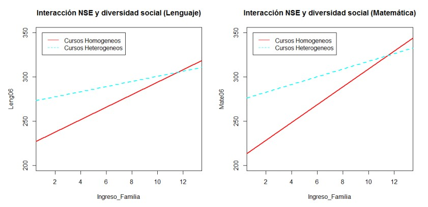

Fuente: Extraído de Taut & Escobar (2012): “El efecto de las características de los pares en el aprendizaje de estudiantes chilenos”

Por último, Ortiz (2015) mediante un análisis residual de regresión compara los puntajes de individuos con un mismo background socioeconómico pero que se encuentran en diferentes colegios según si el colegio es homogéneo o heterogéneo socialmente. De este modo, el autor observa que las pérdidas en términos de puntaje debido a la asistencia a uno u otro tipo de establecimiento tendría una magnitud significativa. Según los hallazgos encontrados, los estudiantes de los dos primeros quintiles (es decir, el 40% más pobre) obtendrían entre 40 y 57 puntos más en la prueba SIMCE cuando se encuentran en una escuela de alumnos aventajados socialmente en comparación a lo que obtienen cuando estudian en un colegio de estudiantes desfavorecidos. Entonces, la inclusión social tendría un impacto positivo en los estudiantes más pobres sugiriendo la necesidad de implementar políticas educativas que promuevan la igualdad y equidad en el sistema escolar.

## Efecto de composición de género

Las diferencias de rendimiento según el género son de suma relevancia. Uno de los principales factores que ha sido aducido como predictor de las diferencias salariales entre hombres y mujeres es la brecha existente que tienen en el puntaje de matemática (Koedel & Tyhurst, 2012).

Uno de los estudios que reviste de mayor robustez en los estudios educacionales de género concluye que la brecha en matemática se logra reducir a la mitad cuando, en un mismo establecimiento educacional, las mujeres se encuentran separadas de los hombres (Paredes, 2018). La literatura ha mencionado que esto podría deberse a que se refuerzan los estereotipos y prejuicios de género cuando ambos géneros comparten la sala de clases (Bertrand, 2011).

En la misma línea que Paredes (2018), un estudio efectuado en el sistema educacional belga tiene hallazgos relativamente similares. Los investigadores se centran en el efecto que tienen aulas/colegios en las que hay un sólo género y aulas compartidas en el rendimiento que tienen hombres y mujeres en matemática y lenguaje (Van de gaer et al., 2004). Para los hombres, la composición de género de la clase tiene más impacto que la composición de género del colegio, mientras que para las mujeres ocurre al revés. En consecuencia, los hombres incrementan su rendimiento en lenguaje (y no en matemáticas) en aulas mixtas y a las mujeres, les va mejor en matemática (pero no en lenguaje) en colegios de un sólo género que en colegios mixtos.

Dumay & Dupriez (2008), también para el caso belga, obtienen resultados relativamente similares. La mixtura por género no tiene un efecto positivo en el aprendizaje en matemática para los hombres, pero sí en sus resultados en lenguaje. Al mismo tiempo, los colegios mixtos perjudican el aprendizaje de matemática de las mujeres quienes obtienen peores resultados en este tipo de establecimientos.

Un estudio para Estados Unidos realizado en la zona de Texas encuentra que una mayor heterogeneidad de género en términos de mayor proporción de mujeres en el aula produce un efecto positivo en el rendimiento de matemática de los hombres, sin afectar de modo significativo el resultado obtenido por las mujeres de la misma sala de clases (Hoxby, 2000).

Evidencia algo contradictoria encuentran otros autores que han indagado en tópicos de género. Según Villalobos et al. (2016) la composición de género no desempeña un papel primordial en las dos variables recién mencionadas. De esta forma “la educación exclusiva para un solo género en Chile no genera mejores resultados académicos ni tiene efectos claros en el ambiente social escolar, dando así cuenta de la necesidad de incorporar la variable de género como un componente fundamental de la inclusión educativa” (Villalobos et al., 2016, p. 10).

Similar a lo hallado por Villalobos, una serie de estudios internacionales han encontrado resultados afines. A partir de Bone (1983), en su estudio acerca de la diferencia en términos de rendimiento académico de los establecimientos educacionales de los colegios de un solo género para alumnos británicos, identifica que las diferencias son mínimas una vez que se controla por ciertas variables, especialmente, aquellas asociadas a los procesos de admisión.

En Irlanda, se respalda la hipótesis anterior, en virtud de los hallazgos obtenidos por Hannan et al. (1996). No hay diferencias significativas en el rendimiento académico cuando comparamos colegios mixtos con colegios no mixtos. Esta discusión reviste de una importancia trascendental en Irlanda en la medida que alrededor de un tercio de los establecimientos se componen de alumnos de un solo género.

Con el espíritu de sistematizar los hallazgos vinculados a las diferencias de rendimientos entre colegios mixtos y no mixtos Smyth (2010) subraya que, de 39 estudios revisados sobre el tópico, 23 de ellos encontraban un efecto casi nulo o insignificante de la composición de género mixta, en 15 de ellos había resultados favorables a una composición de un solo género, y tan sólo uno del total de los estudios tenía resultados positivos para establecimientos mixtos.

En el mismo campo de estudio, Taut & Escobar (2012) encuentran que a las mujeres les va peor comparativamente que a los hombres en matemática y a estos últimos mejor en lenguaje cuando se encuentran en colegios mixtos. A su vez, otro resultado interesante a destacar es que una mayor proporción de mujeres en la sala de clases se asocia con un mayor rendimiento en matemática de los hombres, no obstante, siguen exhibiendo peores métricas que los hombres (en matemática).

Consistente con los resultados encontrados por Taut y Escobar, Radovic Sendra (2017) prueba que las diferencias de rendimiento en matemática entre niñas y niños son persistentes en el tiempo según la prueba SIMCE, pues tanto los alumnos de cuarto como de octavo básico muestran diferencias significativas. No obstante, el género del o la estudiante sólo logra explicar un 1% de la varianza de los resultados. Asimismo, las diferencias de género sólo alcanzan, como máximo, un 20% de una desviación estándar. Por último, un resultado novedoso que exhibe el estudio es la interacción significativa entre el género y el nivel socioeconómico de los estudiantes. En ese sentido, las diferencias de género en matemática van decreciendo a medida que los individuos tienen un mayor nivel socioeconómico.

## Efecto de composición migrante y étnica

La literatura internacional muestra que los estudiantes que sufren de mayor segregación étnica y racial tienen bajos rendimientos en tareas de tipo intelectual, baja motivación y bajos niveles de formación cívica (McEwan, 2008).

La investigación en composición étnica y migrante proviene, fundamentalmente, de Europa. La evidencia nos señala que hay un consenso establecido acerca de los efectos positivos que tiene para las minorías étnicas el pertenecer a escuelas con mayor mixtura pero evidencia más contradictoria con respecto al eventual efecto negativo en el desempeño logrado por las minorías étnicas cuando se encuentran en establecimientos con bajo nivel de diversidad étnica-cultural [Driessen (2001); Dronkers & Levels (2007); Szulkin & Jonsson (2007); van Ewijk & Sleegers (2009); Van Houtte & Stevens (2010); Agirdag et al. (2012)).

El caso estadounidense es ilustrativo al respecto. Aun cuando se han implementado elaboradas políticas de inclusión étnica y migrante en términos de propender hacia una mayor mixtura social, la evidencia empírica acumulada para este país ha logrado demostrar que las diferencias en aprendizaje entre estudiantes migrantes y no migrantes se logran reducir de forma más pronunciada cuando los migrantes se encuentran en establecimientos homogéneos, esto es, con sujetos del mismo origen étnico (es importante aclarar que, en la literatura internacional, dentro de un mismo grupo étnico se consideran varios países. Por ejemplo, el grupo étnico o racial “asiático” incluye países como corea del sur y japón) (Merry & Driessen, 2012).

Uno de los programas de inclusión social más importantes que se han hecho en EEUU, buscando equilibrar cuantitativamente una composición cultural mixta, encontró resultados interesantes. El programa, denominado METCO, realizado en la ciudad de Boston de Estados Unidos, consistía en transferir estudiantes de colegios con una concentración de alumnos no blancos mayor a 50% a establecimientos con una proporción de estudiantes no blancos menor a 30%. Los resultados de la investigación señalan (Angrist & Lang, 2004), contrario a la mayoría de la evidencia en la materia, que un aumento de las minorías étnicas/culturales en la sala de clases no produce una merma en el rendimiento de la mayoría de los estudiantes. Además, de los efectos observados, el único que pareciera ser relevante, aunque de baja magnitud, sería el impacto negativo de la composición racial en la población negra que ya se encontraba en los establecimientos en los cuales se produjo la llegada de estudiantes del programa METCO (Esto es, estudiantes no-blancos que se hallaban en colegios con alta concentración de pares similares).

En Inglaterra, se llevó a cabo un estudio (Smyth, 2010) en 18 escuelas con una composición multiétnica cada una, testeando la hipótesis del efecto que poseía la mixtura cultural. La investigación constata que tanto la puntuación obtenida en matemática como la obtenida en lenguaje no se ve afectada por la composición étnica pero sí por el rendimiento previo que tenían los alumnos y también por la proporción de estudiantes de alto logro en la sala de clases.

En Suecia se efectuó un estudio que documenta el impacto negativo que tiene la alta concentración de estudiantes migrantes en las escuelas en el rendimiento tanto de ellos mismos como de estudiantes nativos. Logran demostrar que cuando hay una concentración o densidad étnica mayor a 40% en la sala de clases, es decir, una proporción de estudiantes migrantes que supere ese límite genera fuertes efectos negativos en las notas que obtienen los estudiantes del establecimiento. De este modo, se sugiere que políticas educativas que contrarresten la segregación generaría impactos positivos tanto en términos de eficiencia como de reducción de la brecha educacional entre los estudiantes (Szulkin & Jonsson, 2007).

Harker & Tymms (2004), en su estudio acerca del sistema educacional neozelandés constatan que la varianza que hay en el puntaje de los individuos entre escuelas se explica casi exclusivamente por el nivel socioeconómico promedio de los establecimientos educacionales. El rendimiento previo de los estudiantes y el grado de concentración étnica es irrelevante en términos estadísticos para efectos de capturar la varianza de puntaje entre las escuelas de Nueva Zelandia. Es interesante subrayar que encuentran un impacto similar para las tres pruebas tradicionales aplicadas, a saber, lenguaje, matemática, y ciencias.

Con una lógica similar, un estudio acerca del sistema educacional alemán (Van der Slik et al., 2006) integra en su medición del efecto composición el nivel socioeconómico promedio del aula y la proporción de estudiantes de otras etnias. Los resultados indican que los estudiantes que están en salas de clases con una alta proporción de estudiantes de otras etnias obtienen peores resultados en las pruebas de lenguaje que aquellos estudiantes que están en aulas con baja proporción de estudiantes de diverso origen étnico. Lo interesante del estudio es que al momento de perfeccionar la medición del estatus socioeconómico promedio (añadiendo variables como si la madre está empleada y la variación de los ingresos del padre en el último tiempo), el impacto de la composición étnica deja de ser significativo.

Indagando con mayor precisión en el efecto de la presencia de inmigrantes en la sala de clases, Contini (2013) prueba que una mayor concentración de migrantes tiene un efecto negativo pero diferenciado en el rendimiento académico de los alumnos. De este modo, los migrantes se ven más perjudicados que los nativos por la presencia de migrantes y, entre los nativos, aquellos de nivel socioeconómico más bajo experimentan una mayor baja en su rendimiento que el resto. Todos los efectos negativos encontrados tienen una magnitud baja, razón por la cual las preocupaciones acerca de una eventual merma significativa en las puntuaciones académicas de los italianos, producto de la oleada de inmigrantes, carece de fundamentos empíricos.

Tomando como referencia el sistema educacional de 17 países europeos, Dronkers & van der Velden (2013), someten a contraste empírico la influencia que tiene la diversidad cultural (incluyendo la etnia y el origen migrante), en el rendimiento académico de estudiantes nativos como de origen migrante, encontrando resultados ostensiblemente ambivalentes. Por un lado, aseveran que una mayor diversidad étnica de la sala de clases produce una merma considerable del puntaje obtenido en habilidades idiomáticas de estudiantes con origen migrante. Mientras, para los estudiantes nativos, el efecto negativo de la diversidad étnica sólo ocurre en aquellos países con sistemas educacionales altamente estratificados en términos sociales.

Por otro lado, la presencia de ciertos grupos étnicos generaría efectos positivos en el aprendizaje del conjunto diverso que compone la sala de clases. Concretamente, la presencia de estudiantes asiáticos (no islámicos) aumentaría el puntaje obtenido en pruebas de idioma de individuos nativos, inmigrantes no asiáticos, y también en los mismos migrantes asiáticos no islámicos. El efecto más fuerte de la presencia de alumnos asiáticos sería para los mismos alumnos asiáticos, aumentando en 16 puntos por cada 10% adicional de estudiantes que provengan de esa región. Por su parte, para inmigrantes no asiáticos y alumnos nativos el grado de influencia sería de 7 y 5 puntos respectivamente cada 10% adicional de asiáticos no islámicos.

Se vuelve fundamental relevar que para ninguno de los otros grupos étnico/migrantes analizados en el estudio se observa un patrón de relación positiva como el que hay a partir de la presencia de migrantes asiáticos no islámicos. Por el contrario, la presencia de estudiantes del Oeste de Europa impacta negativamente en los resultados obtenidos en idiomas por los estudiantes nativos (Dronkers & van der Velden, 2013). Como sugerencia de política educativa, teniendo a la vista 17 sistemas educacionales de los países más influyentes del continente europeo, se encuentra evidencia contradictoria acerca de las consecuencias derivadas de la mixtura cultural en el rendimiento académico. Pareciera ser que hay determinadas circunstancias en las cuales una mayor homogeneidad cultural puede traer resultados positivos para los estudiantes (ejemplo de estudiantes asiáticos no islámicos que potencian fuertemente el rendimiento de estos a medida que aumenta su presencia).

El estudio detallado de la composición cultural de las escuelas en Chile no ha recibido mayormente la atención de los especialistas. Uno de los más importantes antecedentes académicos (de carácter cualitativo) donde se investiga la sala de clases enfatizando en las culturas migrantes (Riedemann & Stefoni, 2015; Tijoux, 2013) concluye que los estudiantes de origen inmigrante están expuestos constantemente a fuertes prejuicios y modos de discriminación que propician un ambiente escolar hostil para ellos. En consecuencia, es posible inferir que, aun cuando no orientan el estudio desde una perspectiva en la dirección aquí planteada, proporcionan ciertas luces sobre la conflictiva integración de las culturas subalternas en la sala de clases, insinuando una eventual relación negativa de escuelas mixtas culturalmente y las puntuaciones obtenidas por las minorías culturales.

Asimismo, el nivel de integración de los migrantes difiere según el país de origen de cada uno de ellos (Castillo et al., 2018). Quienes se encuentran más marginados, en términos de relaciones de amistad, son aquellos de procedencia haitiana y colombiana, mientras que los bolivianos y peruanos están más integrados en las salas de clases. Según los hallazgos, las tensiones producidas al interior de la sala de clases entre nacionales y migrantes ocurren con mayor frecuencia para el caso de haitianos y colombianos. De todos modos, los resultados sugieren que, a nivel genérico, cuando la proporción de migrantes y no migrantes está más equilibrada o con mayor concentración migrante, los conflictos en la sala de clases son mayores.

La investigación más reciente en temas de inclusión educativa de la población migrante, consigna que hay un sesgo sistemático de parte de los docentes a interactuar menos con alumnos que tengan origen migrante, en la asignatura de matemáticas (Ortega et al., 2020). También, es importante destacar a partir de la investigación, que aquellas aulas con mayor composición migrante no logran generar, de forma consistente, una mayor interacción alumno-docente para el caso de los migrantes.

En materia étnica, la primera contribución en la materia (McEwan, 2004) advierte una diferencia de puntaje que se ubica en torno a 0.3-0.5 desviaciones estándar entre población mapuche y no mapuche. La investigación tiene algunas deficiencias importantes, pues determina el origen étnico considerando si la madre pertenece a la etnia mapuche o no. De esta forma, sugieren la relevancia de considerar los efectos de composición étnica para poder dilucidar las diferencias existentes entre establecimientos públicos y privados.

Undurraga (2014), en su tesis doctoral, utiliza una medición distinta para identificar a los alumnos mapuche. Tomando como proxy la auto identificación étnica de los padres, constatan que las diferencias entre mapuches y no mapuches en el SIMCE se encuentran entre las 0,2-0,3 desviaciones estándar, según la prueba que se considere. Una de las principales variables que explicaría esta diferencia sería el nivel socioeconómico individual de los estudiantes, mientras que la composición étnica tendría un efecto negativo en el rendimiento en matemática y ciencias, que vendría mediado, según lo señalado por el autor, por las bajas expectativas que tienen los docentes de sus alumnos cuando hay una alta concentración de estudiantes indígenas.

Asimismo, Cerda (2009) confirma que la población mapuche en la Región de la Araucanía (aquella que recoge la mayor cantidad de estudiantes mapuches en Chile) tiene la menor escolaridad promedio y, al mismo tiempo, tiene los puntajes SIMCE más bajos de la región.

Por último, Canales & Webb (2018) visualizan el efecto negativo que tiene la concentración étnica para los estudiantes indígenas. Al cargar con muchas inequidades los estudiantes de este grupo, pues concentran mayores niveles de desmotivación, la calidad de los profesores suele ser más baja, los recursos tanto económicos, culturales, como institucionales son deficientes, su aprendizaje se ve radicalmente afectado. Los mismos autores encuentran que sujetos de origen indígena en aulas diversas o mixtas socialmente tienen muchos mejores resultados en comparación a lo que obtienen en escuelas que acogen a un gran porcentaje de estudiantes indígenas.

# Objetivos de investigación

**Objetivo general de investigación:**

Determinar en qué medida el grado de heterogeneidad de la composición escolar en términos culturales, socioeconómicos y de género, se relaciona con el rendimiento en matemática y lenguaje de estudiantes mujeres, indígenas, migrantes, y de bajo nivel socioeconómico de II medio.

**Objetivos específicos:**

1. Evaluar la relación que tiene la heterogeneidad socioeconómica de los establecimientos escolares con el rendimiento académico de los estudiantes de niveles socioeconómicos más bajos.
2. Evaluar la relación que tiene la composición de género de los establecimientos escolares con el rendimiento de las mujeres en matemática y lenguaje.
3. Evaluar la relación que tiene la heterogeneidad migrante/étnica de los establecimientos escolares con el rendimiento de indígenas y migrantes en matemática y lenguaje.

# Hipótesis de investigación

1. Los alumnos de niveles socioeconómicos más bajos se ven más favorecidos de establecimientos heterogéneos socioeconómicamente que aquellos alumnos de niveles socioeconómicos más altos.
2. Las mujeres se ven beneficiadas en términos del rendimiento que tienen en matemática cuando se encuentran en colegios no mixtos, mientras en lenguaje no hay un efecto significativo de una composición de estas características.
3. Los indígenas y migrantes obtienen mejores resultados cuando se encuentran mezclados con individuos de origen étnico y nacionalidad diverso que cuando están homogéneamente concentrados.

# Metodología

## Datos

La investigación utilizará datos cuantitativos provenientes de fuentes secundarias. Particularmente, se usa información del Sistema Integral de Mejoramiento de la Calidad Educativa (SIMCE). El SIMCE es una prueba (que evalúa las habilidades en Matemática, Ciencias Naturales, Ciencias Sociales, y Lenguaje) que se aplica todos los años, de carácter censal, a estudiantes de 4to, 8vo, y 2do Medio, junto con una serie de cuestionarios que recolectan información de los profesores, apoderados, y los mismos alumnos.

Específicamente, son pruebas de conocimientos curriculares en varios subsectores en la cual no existe una escala estandarizada, sin embargo, para aspectos generales se considera una escala de un mínimo de 100 y un máximo de 400 puntos, con un promedio de 250 y una desviación estándar de 50 puntos. Además de la prueba de conocimientos curriculares, SIMCE recoge información de contexto a través de un cuestionario para los padres de los estudiantes testeados. Este cuestionario tiene como fin indagar sobre el nivel educacional de los padres, el ingreso del hogar, el nivel de satisfacción con el establecimiento, nacionalidad (tanto de padres/madres como alumnos), origen étnico (tanto de padres/madres como de alumnos), entre otros. Usaremos los datos correspondientes para los alumnos que rindieron la prueba en 2do Medio el año 2017.

Las dos fuentes de información usadas, esto es, el cuestionario de los padres y los datos sobre el puntaje de los estudiantes difieren en la cantidad de observaciones. Mientras esta última cuenta con información de 245.197 estudiantes que rindieron la prueba SIMCE, el cuestionario de los padres sólo logra cubrir a 169.824 estudiantes. Como consecuencia de lo anterior, se trabaja, en principio, con 169.824 observaciones. Luego de la limpieza de los datos y considerando los datos pérdidos la muestra con la cual realizamos los analisis es de 147.979 estudiantes distribuidos en 2901 establecimientos a nivel nacional.

## Variables

Tabla 1: Variables independientes a nivel escuela

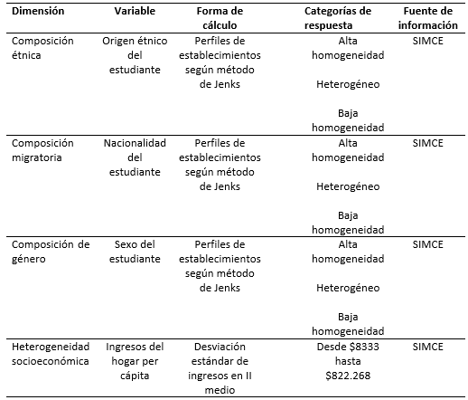

En la tabla adjunta podemos advertir las variables independientes sustantivas de interés. En cada una de ellas, se especifica la forma de cálculo, las categorías de respuesta resultante, y la fuente de información utilizada para extraerlas. Aquí solo enunciaremos cada uno de estos elementos, pues en la sección metodológica se detallará la forma de construcción de variables, las respuestas posibles, y todos los elementos asociados a nuestras variables teóricamente relevantes.

Tabla 2: Variables independientes a nivel individual

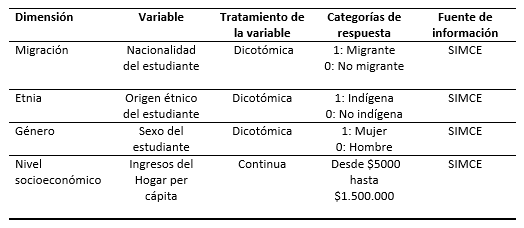

Por otra parte, tenemos las variables independientes sustantivas de orden individual. Al tratarse de datos jerarquizados o de dos niveles, es fundamental distinguir las variables que corresponden a cada uno de los niveles. Mientras en la tabla 1 se mostraron las variables asociadas a los establecimientos escolares, la tabla 2 nos exhibe las variables a nivel individual. Como podrán notar, estas revisten de mayor simplicidad, tanto en su forma de cálculo como en las categorías de respuesta.

Por último, esta investigación tiene como variables dependientes el puntaje obtenido en la Prueba SIMCE Matemática y el obtenido en la Prueba SIMCE Lenguaje 2017

## Análisis

Se estimarán modelos lineales jerárquicos, más conocidos como modelos multinivel para examinar la relación entre las variables a nivel establecimiento escolar (nivel 2) y variables a nivel estudiante (nivel 1), con el puntaje en prueba SIMCE de Matemática y Lenguaje que muestran los estudiantes. La ventaja de este método de estimación radica en la posibilidad de descomponer la varianza de los puntajes de los alumnos entre escuelas, por un lado, y dentro de las escuelas por otro. Lo anterior es posible debido a que los métodos multinivel consideran la estructura anidada de los datos (en este caso alumnos que se encuentran anidados en establecimientos escolares). En ese mismo sentido, permite modelar independientemente la variabilidad en los distintos niveles de agregación y la interacción entre estos niveles.

## Descripción de variables

### Variables nivel estudiante

| **No** | **Variable** | **Label** | **Stats / Values** | **Freqs (% of Valid)** | **Graph** | **Valid** | **Missing** |
| --- | --- | --- | --- | --- | --- | --- | --- |
| 1 | puntaje_leng [numeric] | Puntaje Lenguaje | Mean (sd) : 254.8 (51.1) min < med < max: 116.8 < 255.4 < 397.3 IQR (CV) : 73.5 (0.2) | 21840 distinct values |  | 147979 (100%) | 0 (0%) |
| 2 | puntaje_mate [numeric] | Puntaje Matemática | Mean (sd) : 270.2 (63.4) min < med < max: 96.6 < 272.5 < 428 IQR (CV) : 93.7 (0.2) | 25826 distinct values |  | 147979 (100%) | 0 (0%) |
| 3 | ingresos [numeric] | Ingresos hogar per cápita | Mean (sd) : 167611.4 (185102.6) min < med < max: 5000 < 110000 < 1500000 IQR (CV) : 117500 (1.1) | 106 distinct values |  | 147979 (100%) | 0 (0%) |
| 4 | sexo [haven_labelled, vctrs_vctr, double] | Sexo | Min : 0 Mean : 0.5 Max : 1 | 0 : 72379 ( 48.9% ) 1 : 75600 ( 51.1% ) |  | 147979 (100%) | 0 (0%) |
| 5 | cultura [numeric] | Cultura | Min : 0 Mean : 0.2 Max : 1 | 0 : 116716 ( 78.9% ) 1 : 31263 ( 21.1% ) |  | 147979 (100%) | 0 (0%) |
| 6 | educacion [numeric] | Nivel educativo | Mean (sd) : 12.2 (2.6) min < med < max: 0 < 12 < 17 IQR (CV) : 2 (0.2) | 18 distinct values |  | 147979 (100%) | 0 (0%) |
| 7 | nacionalidad [numeric] | Nacionalidad | Min : 0 Mean : 0 Max : 1 | 0 : 141337 ( 95.5% ) 1 : 6642 ( 4.5% ) |  | 147979 (100%) | 0 (0%) |
| 8 | etnia [numeric] | Etnia | Min : 0 Mean : 0.2 Max : 1 | 0 : 122271 ( 82.6% ) 1 : 25708 ( 17.4% ) |  | 147979 (100%) | 0 (0%) |

Generated by summarytools 0.9.6 ([R](https://www.r-project.org/) version 4.0.2)  
2020-12-13

Si observamos la tabla, contiene todas las variables a nivel estudiante que son de interés en este estudio. Respecto al sexo de los individuos, tenemos que hay casi la misma proporción de hombres y mujeres en la muestra considerada. Los ingresos del hogar, a su vez, utilizados para medir el nivel socioeconomico de los alumnos se construyó a partir de dos variables siguiendo el esquema descrito a continuación: Por una parte, contamos con la variable de ingresos por tramo (siendo el tramo de menor ingreso equivalente a “ganar menos de $100.000”, y el tramo de mayor ingreso igual a ganar más de $2.200.000, con otros trece tramos entre ellos), por otra, con la cantidad de habitantes del hogar. Se imputó a cada estudiante el valor medio entre el rango inferior y superior de cada tramo y, para el caso de la categoría más baja y más alta se imputó la cantidad de $50.000 y $3.000.000 respectivamente. Posteriormente, se dividió el monto en cuestión por la cantidad de habitantes del hogar del estudiante.

A partir de la distribución de la variable podemos notar nítidamente que hay una marcada concentración de los datos hacia la izquierda, cuya asimetría podemos explicar a partir de los bajos ingresos, en promedio, de la población chilena. Más especificamente, la media nacional de ingresos del hogar per cápita alcanza el valor de casi 170 mil pesos, mientras que la mitad de la población gana menos de 110 mil, dando cuenta de la existencia de ingresos mediano-bajos a nivel país. La asimetría de la variable es muy elevada, con una fuerte concentración de los individuos a la izquierda de la distribución.

Ahora bien, si penetramos en las variables dependientes del estudio, tenemos un comportamiento de las variables algo diferente a las anteriores. En primer lugar, los resultados en matematica tienen una mayor variabilidad que los puntajes en la prueba de lenguaje. En efecto, hay un grupo importante de estudiantes que tienden a situarse en la parte más alta (o, si se quiere, más a la derecha si tenemos como eje las abcisas) de la distribución. Ateniendonos a los datos, la prueba de matematica es la que tiene una desviación estandar más alta entre ambas pruebas (63.4 vs 51.1 en lenguaje). Este dato nos indica que hay una mayor desigualdad en los puntajes de matematica que en las otras pruebas, asunto que intentaremos explicar más adelante a partir de ciertos atributos sociales tanto de los individuos como del conjunto agregado a nivel del establecimiento. Acerca de los valores mínimos y máximos observados en cada prueba no hay diferencias significativamente grandes. En matemáticas el mínimo observado es de 96.6 y el máximo de 428 puntos y en la prueba de lenguaje el mínimo 116.8 y el máximo de 397.3.

Por último, la variable nivel educacional data de 18 categorías donde cada valor representa los años de estudio alcanzados exceptuando las últimas categorías. Para su construcción se utilizó el máximo nivel educacional obtenido entre el padre y la madre del estudiante.

Desde el 0 al 13 son los años de estudio donde el 0 indica ningún año de estudio y el 13 representa a aquellos estudiantes donde el nivel educacional máximo por alguno de sus padres es haber terminado el colegio con un año adicional para un titulo técnico “abreviado”. Por otro lado, la categoría 14 representa a aquellos que tienen educación técnica completa, el 15 a quienes terminaron la Universidad, el 16 a quienes alcanzaron el grado de magister, y 17 el grado academico de doctor. Cabe destacar que al menos la mitad de los estudiantes provienen de familias en las cuales no se alcanzó a terminar el colegio (mediana=12). Asimismo, la cantidad de estudiantes que tienen padres con el grado de doctor o magister es muy bajo si observamos el histograma de la variable.

En último término, cabe consignar que se tomó la decisión de no recodificar ingreso y nivel educacional como categoricas en virtud del foco que tiene el estudio en evaluar el impacto de la heterogeneidad social en el rendimiento. Si trataramos estas dos variables como categoricas perderiamos mucha variabilidad de cada una de ellas dejando de capturar la real magnitud del impacto que tiene en el rendimiento academico de los estudiantes. A continuación, veamos las estadísticas descriptivas de nuestras variables consideradas a nivel de los establecimientos escolares.

### Variables nivel establecimiento escolar

Como el foco de esta investigación es la relación entre las diferentes dimensiones de la heterogeneidad social y el rendimiento academico, para cada una de ellas se resolvió una forma diferente de medir dicha heterogeneidad. Para el caso de la variable ingresos, que es tratada como cuantitativa, se utiliza la desviación estándar de cada uno de los establecimientos. La desviación estandar es una buena medida de heterogeneidad en la medida que calcula la dispersión de los datos y, de esa forma, es capaz de capturar cuánto se alejan en promedio cada uno de los datos de la media. Así, un colegio que tenga una mayor desviación estándar tendrá una mayor dispersión en lo que refiere a los ingresos de los estudiantes y, por lo tanto, será más heterogéneo. Debido al cáracter de las otras variables con las cuales se quiere medir heterogeneidad (cultural, étnica, y de género) procedimos a elaborar otra forma de medirla.

En consecuencia, en el caso de las variables dicotómicas sexo, etnia, y nacionalidad se construyeron perfiles de establecimientos a partir del método de “Jenks”. Este modo de clasificar o agrupar una variable consiste en la creación de categorías a partir de determinada variable siguiendo un criterio de minimización de la varianza al interior de cada una de esas categorías o grupos y la maximización entre ellas. Así, el algoritmo optimizará (formará los tramos óptimos para cada categoría) bajo las dos restricciones mencionadas. La virtud de este metodo radica en que no requiere de segundas variables para la creación de las categorías en aquella(s) de interés.

Antes de aplicar el algoritmo de Jenks, se calculó, por cada establecimiento, la proporción de mujeres, índigenas, y migrantes. Luego, con esa información clasificamos a cada una de las tres variables mencionadas según tres categorías o grupos: Homogeneos con alta cantidad de estudiantes de la categoría de referencia, homogeneos con baja cantidad de estudiantes de la categoría de referencia y, por último, heterogeneos que se componen de una cantidad equilibrada de ambas categorías. Veamos con más detalle el puntaje de corte establecido para cada una de las categorías y, luego, según esos puntajes, la distribución porcentual de los establecimientos según cada una de las variables de interés.

Tabla 3: Puntajes de corte para cada variable a partir del método de Jenks

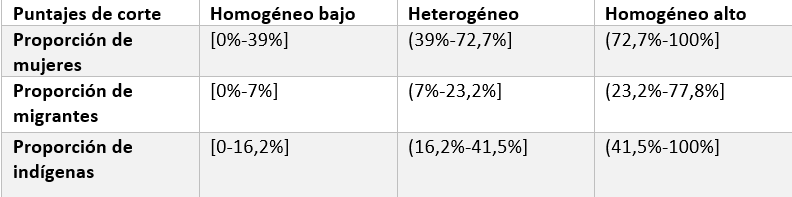

Fuente: Elaboración propia

Tabla 4: Distribución porcentual de establecimientos según grado de heterogeneidad

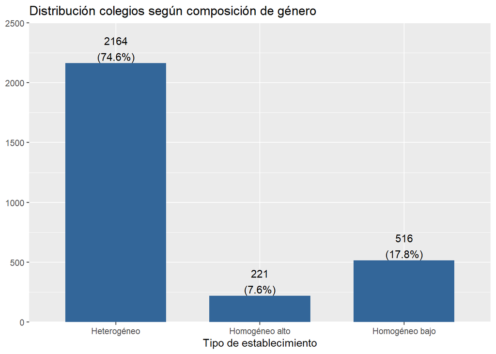

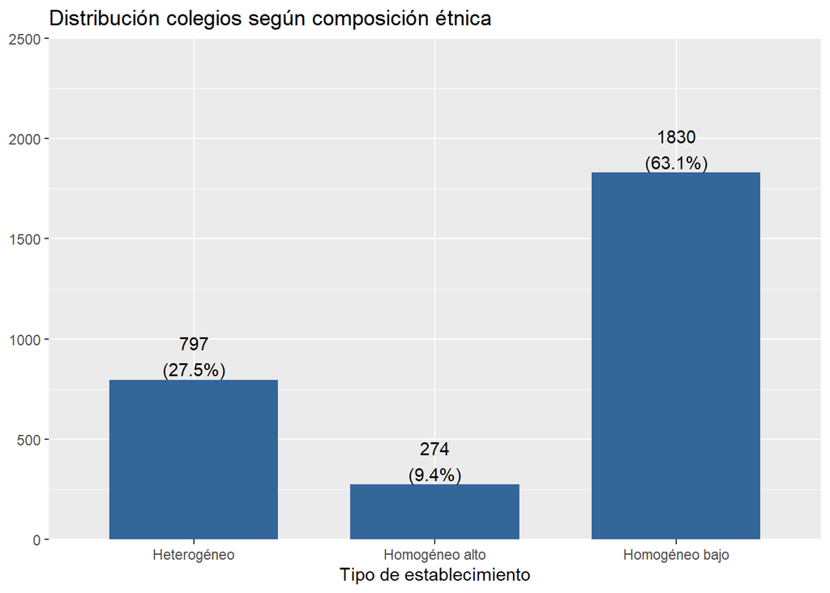

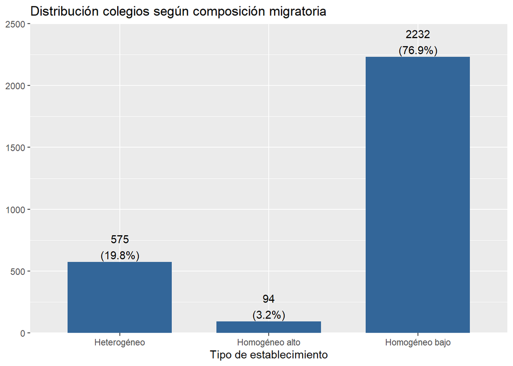

Con la información presente en los gráficos de barra, podemos advertir con precisión, primero, el rango de porcentajes para poder determinar si cierta proporción de mujeres/indígenas/migrantes en el aula representa un colegio homogéneo bajo, heterogéneo, u homogéneo alto en la categoría social correspondiente. Entonces, por ejemplo, un establecimiento que aloja un 20% de mujeres sería clasificado como homogéneo bajo (en términos de género) y un establecimiento con el mismo porcentaje de migrantes sería catalogado como heterogéneo (en términos “migratorios”).

## Correlaciones

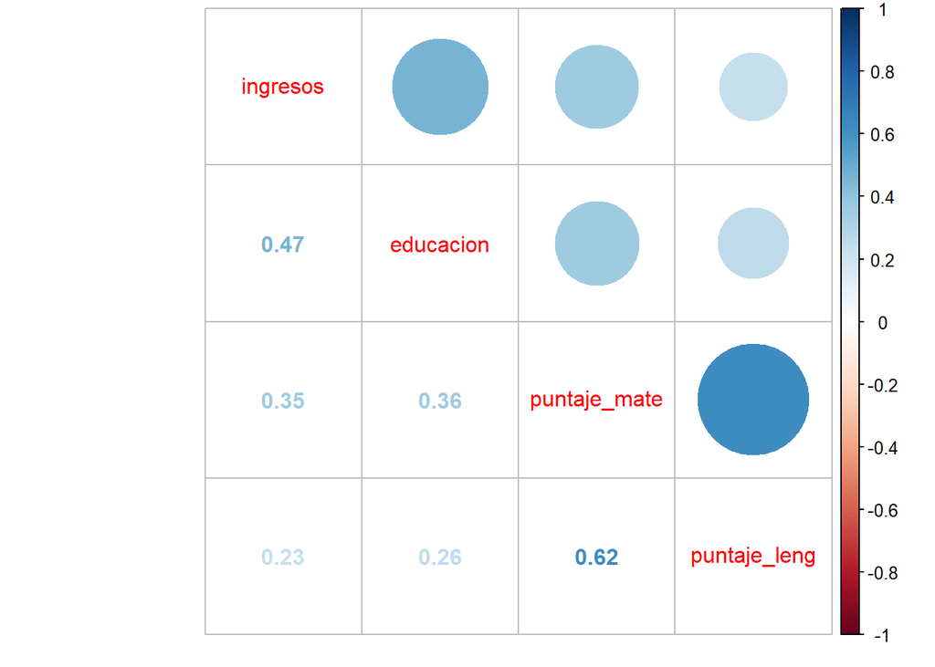

El gráfico de correlaciones entre variables cuantitativas a nivel estudiante (ingresos, puntajes SIMCE, y educación) da cuenta de una asociación alta entre, por un lado, ingreso y educación y, por otro lado, los puntajes en la prueba SIMCE, particularmente la de Matemática. En ese caso, las correlaciones son del orden de 0.35 para el caso de ingresos y 0.36 con la variable educación. Mientras, la correlación entre estas dos variables cuantitativas y el puntaje en lenguaje es más baja que la observada en matemáticas, alcanzando el valor de 0.23 para ingresos y 0.26 para educación. A su vez, se puede apreciar una leve diferencia en favor de la variable educación.

Las correlaciones entre las dos variables independientes cuantitativas a nivel estudiante no es lo suficientemente alta como para poder establecer que están midiendo lo mismo. En consecuencia, está empiricamente justificado la inclusión de ambas variables en el modelo por separado.

## Gráficos bivariados

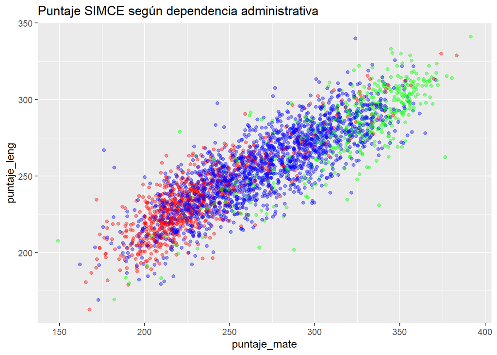

Si evaluamos el gráfico podremos notar la fuerte asociación existente entre los puntajes SIMCE y la dependencia administrativa de los establecimientos escolares. Cada color representa un tipo de dependencia diferente, donde el rojo es para colegios Municipales, el azul para colegios subvencionados, y el verde para colegios particulares pagados. De este modo, existe una jerarquización marcada por puntaje donde aquellos privados obtienen un mejor rendimiento tanto en matemática como en lenguaje, mientras aquellos municipales se concentran en la parte más baja del gráfico. En definitiva, se consolida la idea de que hay una dependencia contextual de los datos, adicional a las correlaciones observadas a nivel estudiante en virtud de la varianza que hay en los puntajes SIMCE entre los diferentes grupos considerados (dependencia administrativa, ingreso, y educación).

# Modelos

## Modelo individual, grupal, y multinivel

En primer lugar, antes de comenzar a describir los párametros de los modelos estimados, es importante mencionar la cantidad de varianza de los puntajes de cada una de las pruebas que hay entre las escuelas chilenas (técnicamente denominada correlación intraclase que se obtiene a partir del modelo nulo). Siguiendo los resultados, tenemos que un 47% de la varianza del puntaje SIMCE Matemática está entre las escuelas. Para el caso de lenguaje la varianza entre escuelas es más baja, del orden de 29%. En consecuencia, se torna pertinente modelar los resultados en la prueba SIMCE considerando la estructura anidada de los datos, pues una porción importante de la varianza de los resultados se explica por la pertenencia a establecimientos escolares.

Si estimamos el modelo de regresión sólo considerando las variables individuales los datos nos muestran que todas las variables que teoricamente formulamos como potencialmente explicativas del rendimiento academico en matemática lo son empiricamente. En ese sentido, todas las variables incluidas son estadisticamente significativas con un nivel de confianza equivalente a un 99%. No obstante, es importante advertir que el comportamiento de los coeficientes difiere según la prueba SIMCE considerada.

Las variables que muestran una relación más fuerte con el puntaje SIMCE de Matematica son, como es esperable, el sexo y los ingresos de los individuos. El ser mujer está asociado a una pérdida de puntajes del orden de 5,45 puntos en comparación a lo obtenido por los hombres. Mientras en el caso de los ingresos tenemos que un incremento del 1% en el ingreso per cápita del hogar significa, en promedio, un aumento de 0,04 puntos en la prueba. O, en un sentido más sustantivo, un individuo que tiene ingresos que ascienden al doble de ingresos que el de otro va a tener, en promedio, 4,05 puntos más en matemática, manteniendo el resto de las variables constantes.

Uno de los resultados más contra intuitivos del modelo individual es que, pese a toda la evidencia acumulada, tanto los indigenas como los migrantes obtienen mejores resultados que quienes no son indígenas y no migrantes, respectivamente. De todos modos, el dato más relevante es aquel referido a nacionalidad cuya significación es muy elevada, pues tiene un 99,9% de confianza. Este resultado podría explicarse por la presencia de migrantes con alto capital cultural y ecónomico, como lo pueden ser migrantes europeos y estadounidenses, por ejemplo.

En el modelo de regresión que sólo incluye las variables de nivel escuela, podemos notar que el factor que tiene una mayor influencia en el rendimiento académico de los colegios es el nivel educativo promedio de una sala de clases, de modo que el coeficiente asociado a dicha variable es de 19.82. En efecto, un colegio que tiene un año más de educación promedio que otro, tendrá una ganancia de puntaje del orden de 20 puntos.

Tanto el promedio de ingreso per cápita del hogar como la desviación estándar del mismo tienen un efecto muy bajo, y sólo en el caso de la media es significativo, con un valor bajo de apenas 0,45. Ahora bien, a partir de los perfiles de establecimientos según el grado de heterogeneidad existente al interior de ellos podemos determinar el resultado derivado de cierto contexto o tipo de mixtura social, cultural, y económica. En ese sentido, en el caso de la nacionalidad, aquellos colegios con baja concentración de migrantes son los que obtienen mejor resultado, comparandolo tanto con los establecimientos heterogéneos como con aquellos que tienen una alta concentración de migrantes. Asimismo, tiene mejores resultados academicos aquellos heterogeneos en términos de migrantes que aquellos homogeneos alto en lo que refiere a la condición migratoria.

En lo que refiere a la composición de género de los establecimientos escolares, es posible aseverar que aquellos establecimientos que tienen un mejor rendimiento agregado son aquellos homogeneos alto o bien que tienen una alta proporción de mujeres en la sala de clases, teniendo como referencia a aquellos colegios con baja concentración de mujeres. En último termino, los establecimientos con alta proporción de índigenas son aquellos que exhiben mejor rendimiento en matemática comparado tanto con los colegios heterogeneos etnicamente como con los con baja homogeneidad étnica.

El modelo multinivel, que considera tanto las variables individuales como las grupales simultaneamente, tiene coeficientes similares a los obtenidos cuando estimamos los modelos por separado. En esa línea, todos mantienen su sentido, y su magnitud tiene diferencias casi imperceptibles.

En el caso de la prueba SIMCE de lenguaje, hay algunas diferencias considerables atendiendo a los párametros estimados. Uno de los elementos más distinguidos de los regresores es que el ser mujer, a diferencia de lo que ocurría en matemática, está asociado a una ganancia de puntaje SIMCE, teniendo como categoría de referencia a los hombres. A su vez, al igual que en matemática, la heterogeneidad en los ingresos de las familias tiene un impacto negativo en el puntaje SIMCE, contrario a la hipótesis formulada. Respecto de nuestras variables independientes a nivel establecimiento escolar ligadas a los perfiles de establecimientos, tenemos algo similar a lo observado en los modelos de regresión estimados para la prueba de Mátematica.

Los colegios con alta proporción de mujeres siguen teniendo mejor rendimiento que los heterogeneos y que los poco homogéneos (o baja proporción de mujeres en la sala de clases). En el caso de los establecimientos agrupados segun el nivel de heterogeneidad migratoria, los datos nos muestran que los que obtienen mejores resultados son aquellas con baja concentración de migrantes (u homogéneos bajo usando la jerga habitual). Para efecto del tipo de composición étnica de los colegios, los modelos son claros en exhibir que aquellos colegios con alta concentración de indígenas son los mejor evaluados comparado tanto con establecimientos heterogeneos etnicamente hablando como homogéneo bajo.

## Modelos multinivel con interacción entre niveles

En la siguiente sección procederemos a evaluar si es que existe algún efecto adicional de los tipos de composición social por pertenecer a algún género, etnia, y nacionalidad. Concretamente, siguiendo las hipótesis de investigación contrastaremos tres aseveraciones empíricas contenidas en ellas. En primer lugar, evaluaremos si la composición de género de los establecimientos tiene un efecto diferente en las mujeres; en segundo lugar, si la composición étnica de las escuelas afecta de modo diferenciado a estudiantes índigenas; y, por último, si acaso la composición migratoria de los colegios tiene algún tipo de efecto adicional en la población migrante. Es importante recordar que en los modelos de regresión ya estimados sólo contrastamos la idea de si la composición social (en los tres tipos considerados) afecta el rendimiento acádemico de los alumnos sin distinguir si el efecto era diferente para las mujeres, índigenas, y migrantes.

### Interacción entre composición socioecónomica y nivel socioeconómico bajo

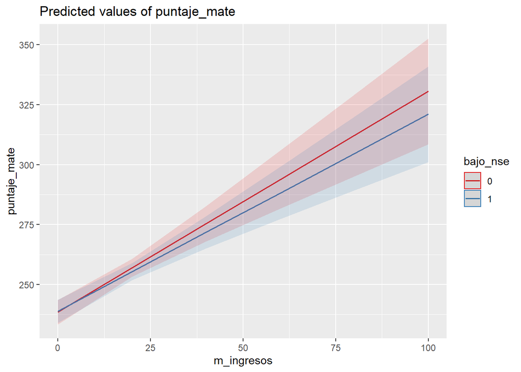

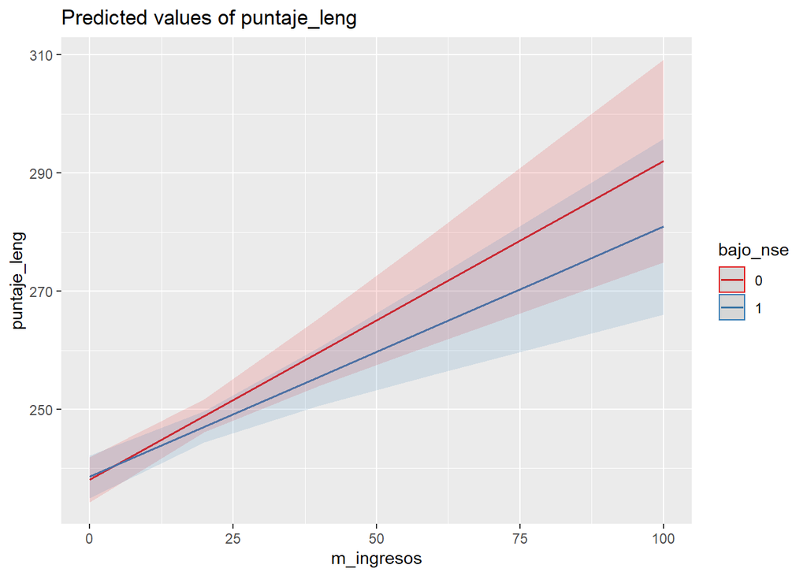

### Interacción entre composición de género y sexo

Comparación modelos con interacción sexo/composición género

|  | Modelo SIMCE Matemática | Modelo SIMCE Lenguaje |
| --- | --- | --- |
| Intercepto | 179.69*** | 191.45*** |
|  | (4.09) | (3.23) |
| Ingresos | 3.15*** | 1.85*** |
|  | (0.19) | (0.18) |
| Mujer | -5.52*** | 14.82*** |
|  | (0.28) | (0.26) |
| Educación | 1.80*** | 1.39*** |
|  | (0.06) | (0.05) |
| Migrante | 2.94*** | 1.18* |
|  | (0.62) | (0.57) |
| Indígena | 0.33 | 0.46 |
|  | (0.35) | (0.32) |
| Heterogeneidad social | -0.42** | -0.32** |
|  | (0.15) | (0.11) |
| Promedio nivel educativo | 15.10*** | 8.74*** |
|  | (0.85) | (0.63) |
| Heterogeneidad educativa | 3.17* | 1.80 |
|  | (1.35) | (1.01) |
| Promedio ingresos | 0.82*** | 0.42*** |
|  | (0.12) | (0.09) |
| Homogeneidad migratoria alta | -13.25*** | -8.03*** |
|  | (3.25) | (2.41) |
| Homogeneidad migratoria baja | 9.29*** | 7.34*** |
|  | (1.34) | (0.99) |
| Homogeneidad étnica alta | 7.20*** | 6.03*** |
|  | (2.08) | (1.53) |
| Homogeneidad étnica baja | 3.24** | 1.52 |
|  | (1.24) | (0.91) |
| Particular Subvencionado | 10.24*** | 4.30*** |
|  | (1.36) | (1.00) |
| Particular Pagado | -5.60 | -5.16 |
|  | (3.74) | (2.79) |
| Alta homogeneidad género | 3.85 | 2.42 |
|  | (2.75) | (2.27) |
| Baja homogeneidad género | -9.69*** | -6.77*** |
|  | (1.40) | (1.04) |
| Interacción mujer homogéneo alto | -0.81 | -0.14 |
|  | (2.05) | (1.87) |
| Interacción mujer homogéneo bajo | -1.31 | -0.58 |
|  | (0.85) | (0.78) |
| AIC | 1565436.42 | 1539096.87 |
| BIC | 1565654.32 | 1539314.77 |
| Log Likelihood | -782696.21 | -769526.43 |
| Num. obs. | 147976 | 147976 |
| Num. groups: rbd | 2898 | 2898 |
| Var: rbd (Intercept) | 695.87 | 354.30 |
| Var: Residual | 2188.26 | 1847.26 |

p < 0.001; p < 0.01; p < 0.05. Errores estándar en paréntesis

Según lo discutido en el análisis de los modelos individual/grupal/multinivel se demostró que, de modo general, aquellos establecimientos con una alta proporción de mujeres tienen un mejor rendimiento académico en ambas pruebas SIMCE. Pero, con esa especificación de los modelos no es posible saber si hay un efecto diferenciado de dicha composición de género dependiendo del sexo de los estudiantes. En virtud de ello, estimamos modelos de regresión con interacción entre niveles, particularmente, entre los perfiles de establecimiento según género y el sexo de los alumnos.

Los resultados muestran, tanto para la prueba de matemática como de lenguaje, que el efecto de estar en un colegio heterogéneo para las mujeres es levemente mayor que para los hombres. Sin embargo, el efecto de un establecimiento con alta proporción de mujeres es un poco mayor para los hombres que para las mujeres (sabiendo que, a nivel agregado, es positivo para los dos) cuando los comparamos con un colegio heterogéneo.

En resumen, es casi nula la diferencia del efecto de composición de género según el sexo de los alumnos, lo cual se ve respaldado en que ninguno de los coeficientes asociados a la interacción entre estas variables resulta ser significativo. Pese a ello, se confirma la hipótesis acerca de la relación entre la composición de género y el rendimiento de las mujeres, pues tanto a ellas como a los hombres les va mejor, en promedio, con una alta proporción de las primeras en el aula.

### Interacción entre composición étnica e indigenas

La interacción entre la composición étnica y el origen étnico de los estudiantes arroja que hay un efecto adicional para los indigenas cuando se encuentran en colegios con alta proporción de su endogrupo en comparación a los resultados que obtienen cuando están en colegios heterogeneos étnicamente o de baja homogeneidad étnica. No obstante, los coeficientes relativos a la interacción entre estas dos variables alcanza un valor nimio y, por ello, no tiene significación estadística.

De esta forma, si bien a la luz de los resultados empíricos aquí obtenidos sabemos que los colegios con alta proporción étnica (u homogeneidad étnica alta) tienen un efecto positivo y significativo en comparación a los heterogeneos y con baja homogeneidad étnica en ambas pruebas SIMCE, el efecto en cuestión no difiere significativamente si se trata de un índigena o no.

### Interacción entre composición migratoria y migrantes

Por último, acerca de la interacción entre la composición migratoria y el estatuto migratorio de los individuos podemos aseverar que las estimaciones nos proporcionan resultados diferentes en función de la prueba SIMCE considerada. Si evaluamos la interacción para la prueba de lenguaje, el efecto adicional de pertenecer a una escuela heterogenea en términos de nacionalidad para los migrantes es negativa. Por el contrario, los migrantes que son parte de escuelas heterogéneas en términos de su composición migratoria tienen un puntaje adicional positivo en comparación a lo obtenido en colegios homogéneos.

Pese a lo anterior, es importante subrayar que los coeficientes asociados a la interacciones estimadas no son significativos estadísticamente, razón por la cual la interpretación aquí ofrecida sólo tiene sentido a nivel muestral (que, por cierto, se parece a la población por tratarse de una muestra muy grande).

# Discusión de los resultados

## Retomando las hipótesis de investigación

La discusión acerca del fenómeno de la segregación social y, más especificamente, de la composición de los establecimientos escolares es fundamental en nuestro país, cuyo contexto educativo exhibe altos niveles de discriminación, estratificación, y segmentación sociocultural de sus estudiantes. En estas circunstancias, nos preguntamos por la relación que hay en el sistema educacional chileno entre, por un lado, el grado de heterogeneidad de la composición escolar y los resultados en la prueba SIMCE de matemática y lenguaje.

Siguiendo dicho objetivo, formulamos tres hipótesis que procuraban recoger los debates en la literatura nacional e internacional sobre el tópico de composición. En primer lugar, acerca del nivel socioeconómico se planteó que mayores niveles de heterogeneidad socioeconómica tendrían un efecto positivo en el conjunto de los estudiantes y que además, iba a tener un efecto positivo adicional en la población más pobre comparada con aquella que tiene más ingresos.

Por una parte, si los alumnos más pobres se cambian a escuelas de mayores niveles de ingreso, ciñiendonos por las predicciones de los modelos, debiesen tener una ganancia de puntaje. Por otra parte, dicha escuela se haría más heterogénea y, con ello, tal como se establece en la estimación, habría un efecto negativo sobre esos mismos estudiantes.

Acerca de nuestra segunda hipótesis, relativa a la composición de género y el rendmiento de las mujeres, los modelos estimados son claros en mostrar que tanto estudiantes hombres como mujeres obtienen un rendimiento ostensiblemente superior cuando se encuentran en colegios homogéneos con alta concentración de mujeres, en comparación a lo obtenido en uno heterogéneo o de baja homogeneidad. Adicionalmente, cuando contrastamos la posibilidad de que dicho efecto fuese más fuerte en mujeres que en los hombres nos encontramos con que en el caso de un colegio heterogéneo comparado con cualquiera de los homogéneos ocurría así, mientras que en el caso de uno homogéneo con alta proporción de mujeres el efecto positivo se hacía más positivo en hombres que en mujeres. De todos modos, las diferencias eran muy pequeñas y no significativas, razón por la cual el resultado más robusto es aquel referido al primer efecto descrito.

En tercer lugar, la hipótesis propuesta en materia étnica y migrante consistente en que una mayor heterogeneidad étnica, para el caso de los indígenas, y migratoria para el caso de los migrantes sería mejor que un ambiente homogéneo en estas dimensiones considerando los resultados académicos, es parcialmente cierto.

En ese sentido, aquellos establecimientos con baja concentración de migrantes (u homogéneo bajo) tienen puntuaciones más altas tanto en matemática como en lenguaje comparado con colegios heterogéneos, no obstante, aquellos establecimientos heterogéneos tienen un mejor rendimiento comparado con aquellos homogéneos alto. En virtud de ello, se puede sostener que tanto para los migrantes como para los nacionales es mejor pertenecer a un colegio heterogéneo según nacionalidad que uno en el cual haya una alta concentración de migrantes.

En la misma línea, en el caso de la composición étnica de las escuelas los resultados son diferentes. Las escuelas heterogéneas obtienen peores resultados comparado con los dos perfiles de homogeneidad étnica (alta y baja) lo cual contraviene directamente lo propuesto acerca de la composición étnica en la tercera hipótesis. De todos modos, cabe subrayar que las escuelas con alta concentración de indígenas puntúan más en las dos pruebas que las con baja concentración de estudiantes de origen indígena.

Desde una perspectiva de política educacional, los productos aquí obtenidos nos permiten consignar algunas orientaciones a la vez que constatar ambieguedades y nudos irresueltos que deben permanecer en constante estudio. Uno de los principales puntos que se desmitifica es que la mixtura social y cultural resulta ser completamente perjudicial. Según los hallazgos, en muchos casos un contexto más heterogéneo es más conveniente que uno homogéneo (tal es el caso para los migrantes y, con alguna salvedad, para los quintiles más pobres) evaluado según el rendimiento académico.

Asimismo, un resultado que confirma la hipótesis de trabajo pero que no está exento de polémicas es el caso de la composición de género. Los resultados nos indican que aquellos establecimientos con una alta proporción de mujeres muestran mejores resultados que aquellos heterogéneos y aquellos con baja homogeneidad. Entonces, la pregunta que emerge a partir de lo anterior es si los colegios se debiesen separar por género en virtud de los mejores resultados mostrados por los colegios con alta cantidad de mujeres. Sabiendo los múltiples beneficios típicos de una educación mixta (citar acá), sumado a que es un proceso muy extendido (sólo un porcentaje muy bajo de colegios abarca estudiantes de un sólo género) se debiese incursionar en las causas y mecanismos que explican que un contexto educativo con esa composición de género sea más favorable que las otras, en relación con el rendimiento académico.

## Limitaciones del estudio

La investigación desarrollada tiene varias limitaciones sumamente relevante de mencionar y a corregir en investigaciones futuras. En primer lugar, los datos con los que se trabajan podrían tener un sesgo significativo en la medida que sólo se trabaja con 148 mil (aproximadamente) de los 270 mil alumnos que rindieron el SIMCE de II medio el año 2017. De todas formas, el tamaño de la muestra alcanzada es grande y, también, la distribución empírica de algunas variables (por ejemplo del ingreso per cápita) se asemeja a lo que ocurre efectivamente en la población chilena (dando luces de que dicho sesgo bien podría ser inexistente).

En segundo lugar, el enfoque metodológico de la investigación es de cáracter transversal lo cual, necesariamente, implica ciertas limitaciones. En consecuencia, no es admisible descartar que el comportamiento observado de los datos se explique por alguna(s) variable(s) de orden longitudinal (por ejemplo, el rendimiento previo de los estudiantes).

En tercer lugar, es posible que hayan variables fundamentales no incluidas que puedan estar muy vinculadas al rendimiento académico de los alumnos. El fenómeno educacional es de gran complejidad, lo cual implica que, al momento de modelar dicho fenómeno, siempre se dejan fuera elementos, componentes, y dimensiones que subyacen a esta problemática.

En cuarto lugar, la forma de construcción del nivel socioecónomico se hizo sólo a partir de los ingresos, pues nos encontramos delimitados por los datos que no tenían más preguntas de caracterización socioecónomica que hubiesen servido para medir de manera más multidimensional dicho constructo.

## Investigaciones futuras

La investigación desarrollada significa una contribución importante en materia de composición escolar y la relación que tiene sus distintas formas de distribución en el rendimiento acádemico. No obstante, el proceso educativo no sólo abarca el cultivo de aptitudes cognitivas de los estudiantes. Por ello, investigaciones futuras debiesen evaluar la relación del fenomeno de la composición escolar con el ambiente generado en la sala, la motivación de los estudiantes, y el desarrollo psicosocial de los alumnos. En medio de un escenario educativo de fragmentación ecónomica, social, y cultural, es fundamental conocer los impactos que ello tiene en la formación de los estudiantes chilenos.

El enfoque con el cual nos aproximamos al tópico investigado tuvo más bien un cáracter descriptivo en el sentido de que buscamos cuantificar y medir empíricamente la relación entre el grado de heterogeneidad de la composición y el puntaje SIMCE. Sumado a lo anterior, es crucial explicitar y profundizar en la discusión normativa que intersecta el estudio de la composición escolar. En ese sentido, no solo cabe preguntarse por la magnitud de la segregación, heterogeneidad/homogeneidad de los colegios, sino también ahondar en la pertinencia o no de un sistema educacional más equitativo, mixto, con una interacción dinámica entre los diversos grupos sociales y culturales que son parte de la sociedad chilena.

En esa línea, la reciente (y aún no culminada) implementación de la nueva ley de eduación pública (que desmunicipaliza la educación pública) y la ley de inclusión, la cual pone fin a la selección y el copago en establecimientos subvencionados va en la dirección de propiciar una mayor equidad social, asentada en la idea de una educación orientada a cultivar la no discriminación, el trato igualitario entre diversos géneros, culturas, grupos sociales y, en definitiva, una mayor cohesión social a nivel del país. Entonces, de algún modo, la tarea para los investigadores en educación es resguardar un diseño que, por un lado, garantize efectivmaente mayor igualdad, mixtura y equidad al interior del sistema educacional y, por otro, sin descuidar los potenciales efectos negativos que podría tener en los resultados académicos (y también otras dimensiones no evaluadas en este estudio) que, en cierto grado, evidenciamos en esta investigación.

Como antecedente fundamental de lo anterior, existe vasta evidencia de sistemas educacionales con niveles de equidad y mixtura social muy alta con, al mismo tiempo, resultados sobresalientes en el proceso formativo de los estudiantes. Tal es el caso de Finlandia, Dinamarca, y muchos otros países Europeos que se caracterizan por tener una educación pública extendida y robusta. Con ello, se demuestra que es completamente posible y factible el desarrollo de un sistema educacional que armonice niveles altos de igualdad y mixtura social con buenos resultados por parte de sus estudiantes. Quizás esto último esté vinculado a lo primero, hipótesis que excede con creces a lo inferible a partir de nuestros resultados.

Finalmente, destacar la imperiosa necesidad de seguir falseando y contrastando las hipótesis formulados mediante la inclusión de otras variables de control que, eventualmente, puedan estar detrás de las diferencias observadas entre perfiles y interacciones contrastados. Con ello, se contribuira a precisar el alcance real que tiene la heterogeneidad de la composicion en los resultados académicos.

# Bibliografía

Agirdag, O., Van Houtte, M., & Van Avermaet, P. (2012). Why Does the Ethnic and Socio-economic Composition of Schools Influence Math Achievement? The Role of Sense of Futility and Futility Culture. *European Sociological Review*, *28*(3), 366–378. https://doi.org/10.1093/esr/jcq070

Alejandro Carrasco,;. G.-H. (2016). *Mercado escolar: Libertad, diversidad y desigualdad*.

Angrist, J. D., & Lang, K. (2004). Does School Integration Generate Peer Effects? Evidence from Boston’s Metco Program. *American Economic Review*, *94*(5), 1613–1634. https://doi.org/10.1257/0002828043052169

Arteaga, F., Paredes, V., & Paredes, R. (2014). School Segregation in Chile: Residence, Copayment or Preferences? *Unpublished Manuscript*.

Atria, F. (2012). *La mala educación: Ideas que inspiran al movimiento estudiantil en Chile* (Primera edición). Catalonia : CIPER, Centro de Investigación Periodística.

Bafalluy, A. P. (1983). *La modernización educacional*. Ediciones Universidad Católica de Chile.

Becker, G. S. (1993). *Human capital: A theoretical and empirical analysis, with special reference to education* (3rd ed). The University of Chicago Press.

Bellei, C. (2007). Expansión de la educación privada y mejoramiento de la educación en Chile. Evaluación a partir de la evidencia. *Pensamiento Educativo*, *40*(1), 285–311.

Bellei, C. (2013). El estudio de la segregación socioeconómica y académica de la educación chilena. *Estudios Pedagógicos (Valdivia)*, *39*(1), 325–345. https://doi.org/10.4067/S0718-07052013000100019

Bellei, C., & Pérez, V. (2010). *Conocer más para vivir mejor. Educación y conocimiento en Chile en la perspectiva del Bicentenario*. Taurus.

Bellei, Muñoz, G., Rubio, X., & Alcaino, M. (2018). *La Nueva Educación Pública. Contexto, contenidos y perspectivas de la desmunicipalización*. LOM Ediciones.

Belleï, C. (2015). *El gran experimento: Mercado y privatización de la educación chilena* (Primera edición). LOM Ediciones.

Bertrand, M. (2011). *New Perspectives on Gender* (pp. 1543–1590) [Handbook of Labor Economics]. Elsevier.

Bonal, X., & Bellei, C. (Eds.). (2019). *Understanding School Segregation: Patterns, Causes and Consequences of Spatial Inequalities in Education*. Bloomsbury Publishing Plc. https://doi.org/10.5040/9781350033542

Bone, A. (1983). *Girls and Girl-only School: Vol. Manchester: Equal Opportunities Commission*. *Manchester: Equal Opportunities Commission*.

Bourdieu, P., & Passeron, J.-C. (2009). *Los herederos: los estudiantes y la cultura*. Siglo Veintiuno Editores Argentina.

Bourdieu, P., Passeron, J. C., Melendres, J., & Subirats, M. (1998). *La reproducción: elementos para una teoría del sistema de enseñanza*. Distribuciones Fontamara.

Canales, A., & Webb, A. (2018). Educational Achievement of Indigenous Students in Chile: School Composition and Peer Effects. *Comparative Education Review*, *62*(2), 231–273. https://doi.org/10.1086/696957

Castillo, D., Santa Cruz-Grau, E., & Vega, A. (2018). Estudiantes migrantes en escuelas públicas chilenas. *Calidad En La Educación*, *49*, 18. https://doi.org/10.31619/caledu.n49.575

Cerda, R. (2009). Situación socioeconómica reciente de los mapuches en la Región de la Araucanía. *Estudios Públicos*, *113*. https://doi.org/10.38178/cep.vi113.445

Coleman, J. (1965). *Equality of Educational Opportunity* (John Hopkins University).

Contini, D. (2013). Immigrant background peer effects in Italian schools. *Social Science Research*, *42*(4), 1122–1142. https://doi.org/10.1016/j.ssresearch.2013.02.003

Contreras, D., Sepúlveda, P., & Bustos, S. (2010). When Schools Are the Ones that Choose: The Effects of Screening in Chile*: School Vouchers in Chile. *Social Science Quarterly*, *91*(5), 1349–1368. https://doi.org/10.1111/j.1540-6237.2010.00735.x

Driessen, G. W. J. M. (2001). Ethnicity, Forms of Capital, and Educational Achievement. *International Review of Education/ Internationale Zeitschrift Fr Erziehungswissenschaft/ Revue Inter*, *47*(6), 513–538. https://doi.org/10.1023/A:1013132009177

Dronkers, J., & Levels, M. (2007). Do School Segregation and School Resources Explain Region-of-Origin Differences in the Mathematics Achievement of Immigrant Students? *Educational Research and Evaluation*, *13*(5), 435–462. https://doi.org/10.1080/13803610701743047

Dronkers, J., & van der Velden, R. (2013). Positive but also Negative Effects of Ethnic Diversity in Schools on Educational Performance? An Empirical Test Using PISA Data. In M. Windzio (Ed.), *Integration and Inequality in Educational Institutions* (pp. 71–98). Springer Netherlands. https://doi.org/10.1007/978-94-007-6119-3_4

Dumay, X., & Dupriez, V. (2008). Does the school composition effect matter? Evidence from Belgian data. *British Journal of Educational Studies*, *56*(4), 440–477. https://doi.org/10.1111/j.1467-8527.2008.00418.x

Elacqua, G. (2012). The impact of school choice and public policy on segregation: Evidence from Chile. *International Journal of Educational Development*, *32*(3), 444–453. https://doi.org/10.1016/j.ijedudev.2011.08.003

Flores, C. (2006). *Consecuencias de la segregación residencial: Teoría y métodos*. 197–230.

Garcia-Huidobro, J. (2007). Desigualdad educativa y segmentación del sistema escolar. Consideraciones a partir del caso chileno. In *undefined*. /paper/Desigualdad-educativa-y-segmentaci%C3%B3n-del-sistema-a-Garcia-Huidobro/019fba1be198f3223624efad75744f69dfb3b299.

González, R. (2017). Segregación educativa en el sistema chileno desde una perspectiva comparada. *Centro de Estudios Del Ministerio de Educación. Santiago. Chile*.

Gray, J., Jesson, D., & Sime, N. (1990). Estimating Differences in the Examination Performances of Secondary Schools in Six LEAs: A multi-level approach to school effectiveness. *Oxford Review of Education*, *16*(2), 137–158. https://doi.org/10.1080/0305498900160201

Hannan, D., Smyth, E., McCullagh, J., O’Leary, R., & McMahon, D. (1996). *Coeducation and Gender Equality: Exam Performance, Stress and Personal Development*. Oak Tree Press in association with the ESRI.

Hansen, M. N. (1997). Social and Economic Inequality in the Educational Career: Do the Effects of Social Background Characteristics Decline? *European Sociological Review*, *13*(3), 305–321. https://doi.org/10.1093/oxfordjournals.esr.a018220

Harker, R., & Tymms, P. (2004). The Effects of Student Composition on School Outcomes. *School Effectiveness and School Improvement*, *15*(2), 177–199. https://doi.org/10.1076/sesi.15.2.177.30432

Hernández, M., & Raczynski, D. (2015). Elección de escuela en Chile: De las dinámicas de distinción y exclusión a la segregación socioeconómica del sistema escolar. *Estudios Pedagógicos (Valdivia)*, *41*(2), 127–141. https://doi.org/10.4067/S0718-07052015000200008

Hoxby, C. (2000). *Peer Effects in the Classroom: Learning from Gender and Race Variation* (Working Paper Nos. 7867; Working Paper Series). National Bureau of Economic Research. https://doi.org/10.3386/w7867

Hoxby, C. M., & Weingarth, G. (2005). *Taking race out of the equation: School reassignment and the structure of peer effects*. 44.

James, D. R., & Taeuber, K. E. (1985). Measures of Segregation’in NB Tuma. *Sociological Methodology*.

Jofre, G. (1988). *El Sistema de subvenciones en educación: La experiencia chilena*. Centro de Estudios Publicos.

Koedel, C., & Tyhurst, E. (2012). Math skills and labor-market outcomes: Evidence from a resume-based field experiment. *Economics of Education Review*, *31*(1), 131–140. https://doi.org/10.1016/j.econedurev.2011.09.006

Mayol, A. (2015). *El derrumbe del modelo: la crisis de la economía de mercado en el Chile contemporáneo*. LOM Ediciones.

McEwan, P. J. (2004). The Indigenous Test Score Gap in Bolivia and Chile. *Economic Development and Cultural Change*, *53*(1), 157–190.

McEwan, P. J. (2008). Can Schools Reduce the Indigenous Test Score Gap? Evidence from Chile. *The Journal of Development Studies*, *44*(10), 1506–1530. https://doi.org/10.1080/00220380802265223

Merry, M. S., & Driessen, G. (2012). Equality on Different Terms: The Case of Dutch Hindu Schools. *Education and Urban Society*, *44*(5), 632–648. https://doi.org/10.1177/0013124511404887

Mizala, A., & Torche, F. (2012). Bringing the schools back in: The stratification of educational achievement in the Chilean voucher system. *International Journal of Educational Development*, *32*(1), 132–144. https://doi.org/10.1016/j.ijedudev.2010.09.004

Murillo, F. J., Duk, C., & Garrido, C. M. (2018). Evolución de la segregación socioeconómica de las escuelas de América Latina. *Estudios Pedagógicos*, *44*(1), 157–179. https://doi.org/10.4067/S0718-07052018000100157

Nash, R. (2003). Is the School Composition Effect Real?: A Discussion With Evidence From the UK PISA Data. *School Effectiveness and School Improvement*, *14*(4), 441–457. https://doi.org/10.1076/sesi.14.4.441.17153

Nash, R., & Harker, R. K. (1997). *Progress at school: Final report to the ministry of education*. Wellington: Ministry of Education.

Nuñez Prieto, I. (2015). Educación chilena en la República: Promesas de universalismo y realidades de inequidad en su historia. *Psicoperspectivas*, *14*(3), 5–16. https://doi.org/10.5027/psicoperspectivas-Vol14-Issue3-fulltext-617

Núñez, I. (1984). *Las transformaciones educacionales bajo el Régimen Militar. Programa Interdisciplinario de Investigaciones en Educación* (Programa Interdisciplinario de Investigaciones en Educación, PIIE).

OECD. (2016). *PISA 2015 Results (Volume I): Excellence and Equity in Education*. OECD. https://doi.org/10.1787/9789264266490-en

Opdenakker, M.-C., & Damme, J. (2001). Relationship between School Composition and Characteristics of School Process and their Effect on Mathematics Achievement. *British Educational Research Journal*, *27*(4), 407–432. https://doi.org/10.1080/01411920120071434

Ortega, L., Boda, Z., Treviño, E., Arriagada, V., Gelber, D., & Escribano, M. del R. (2020). The centrality of immigrant students within teacher-student interaction networks: A relational approach to educational inclusion. *Teaching and Teacher Education*, *95*, 103126. https://doi.org/10.1016/j.tate.2020.103126

Ortiz, I. (2015). Escuelas inclusivas en el contexto de segregación social del sistema escolar chileno. *Calidad En La Educación*, *42*, 93–122. https://doi.org/10.4067/S0718-45652015000100004

Palet, A., Aguirre, P. de, & Chile, P. (Eds.). (2017). *Desiguales: Orígenes, cambios y desafíos de la brecha social en Chile*. PNUD : Uqbar Editores.

Paredes, V. (2018). Mixed but not Scrambled Gender Gaps in Single-Sex Classrooms. In *Working Papers* (Nos. wp470). University of Chile, Department of Economics.

Radovic Sendra, D. (2017). Diferencias de género en rendimiento matemático en Chile. *Revista Colombiana de Educación*, *74*, 221. https://doi.org/10.17227/rce.num74-6907

Riedemann, A., & Stefoni, C. (2015). Sobre el racismo, su negación, y las consecuencias para una educación anti-racista en la enseñanza secundaria chilena. *Polis (Santiago)*, *14*(42), 191–216. https://doi.org/10.4067/S0718-65682015000300010

Sammons, P., Thomas, S. M., & Mortimore, P. (1997). *Forging Links: Effective Schools and Effective Departments*.

Smyth, E. (2010). Single-sex Education: What Does Research Tell Us? *Revue Française de Pédagogie*, *171*, 47–58. https://doi.org/10.4000/rfp.1896

Szulkin, R., & Jonsson, J. O. (2007). Ethnic Segregation and Educational Outcomes in Swedish Comprehensive Schools. In *SULCIS Working Papers* (2007:2). Stockholm University, Linnaeus Center for Integration Studies - SULCIS.

Taut, S., & Escobar, J. (2012). El efecto de las características de los pares en el aprendizaje de estudiantes chilenos de enseñanza media. *MINISTERIO DE EDUCACION*.

Thrupp, M., Lauder, H., & Robinson, T. (2002). School composition and peer effects. *International Journal of Educational Research*, *37*(5), 483–504. https://doi.org/10.1016/S0883-0355(03)00016-8

Tijoux, M. E. (2013). Las escuelas de la inmigración en la ciudad de Santiago: Elementos para una educación contra el racismo. *Polis (Santiago)*, *12*(35), 287–307. https://doi.org/10.4067/S0718-65682013000200013

Treviño, E., Morawietz, L., Villalobos, C., Villalobos, E., & Centro de Estudios de Políticas y Prácticas en Educación (Chile) (Eds.). (2017). *Educación intercultural en Chile: Experiencias, pueblos y territorios*. Centro UC Estudios de Políticas y Prácticas en Educación–CEPPE : Ediciones UC.

Treviño, E., Valenzuela, J., & Villalobos, C. (2014). Segregación académica y socioeconómica al interior de la escuela. Análisis de su magnitud, evolución y principales factores explicativos. *Fonide*.

Undurraga, E. (2014). *Unraveling Development: Three Essays on Structural Determinants of Human Capabilities* [PhD thesis]. Brandeis University.

Valenzuela, J. P., Bellei, C., & De los Rios, D. (2008). *Evolución de la segregación socioeconómica de los estudiantes chilenos y su relación con el financiamiento compartido*.

Valenzuela, J. P., Bellei, C., & Ríos, D. de los. (2014). Socioeconomic school segregation in a market-oriented educational system. The case of Chile. *Journal of Education Policy*, *29*(2), 217–241. https://doi.org/10.1080/02680939.2013.806995

Van de gaer, E., Pustjens, H., Van Damme, J., & De Munter, A. (2004). Effects of single-sex versus co-educational classes and schools on gender differences in progress in language and mathematics achievement. *British Journal of Sociology of Education*, *25*(3), 307–322. https://doi.org/10.1080/0142569042000216963

Van der Slik, F. W. P., Driessen, G. W. J. M., & De Bot, K. L. J. (2006). Ethnic and Socioeconomic Class Composition and Language Proficiency: A Longitudinal Multilevel Examination in Dutch Elementary Schools. *European Sociological Review*, *22*(3), 293–308. https://doi.org/10.1093/esr/jci058

van de Werfhorst, H. G. (2014). Changing societies and four tasks of schooling: Challenges for strongly differentiated educational systems. *International Review of Education*, *60*(1), 123–144. https://doi.org/10.1007/s11159-014-9410-8

van Ewijk, R., & Sleegers, P. (2009). *The Effect of Peer Socioeconomic Status on Student Achievement: A Meta-Analysis* (SSRN Scholarly Paper ID 1402645). Social Science Research Network. https://doi.org/10.2139/ssrn.1402645

Van Houtte, M., & Stevens, P. (2010). School ethnic composition and aspirations of immigrant students in Belgium. *British Educational Research Journal*, *36*(2), 209–237. https://doi.org/10.1080/01411920902802180

Vazquez, E. (2016). Segregación escolar por nivel socioeconómico. Midiendo el fenómeno y explorando sus determinantes. *Economica*, *LXII*, 121–184.

Villalobos, C., Ramírez, P., Infante, I., Wyman, I., Villalobos, C., Ramírez, P., Infante, I., & Wyman, I. (2020). Composición del alumnado en escuelas chilenas: un análisis multidimensional sobre la diversidad del sistema escolar. *Educação &Amp; Sociedade*, *41*. https://doi.org/10.1590/es.205698

Villalobos, C., Wyman San Martín, I., Schiele Muñoz, B., & Godoy Ossa, F. (2016). Composición de género en establecimientos escolares chilenos: Afecta El rendimiento académico y el ambiente escolar? *Estudios Pedagógicos (Valdivia)*, *42*(2), 379–394. https://doi.org/10.4067/S0718-07052016000200022